# PROJECT PENAMBANGAN DATA

## KLASIFIKASI DATASET DRY BEAN

Project ini bertujuan untuk mencari model machine learning terbaik yang dapat memprediksi klasifikasi dari dataset **Dry Bean.** serta akan melakukan implementasi model tersebut kedalam web menggunakan Python dengan framework Flask.

# DATA UNDERSTANDING

Tahap ini mencakup empat cara untuk memahami data, yaitu memahami cara memperoleh data, eksplorasi data, mengetahui tipe data pada setiap kolom, dan mengidentifikasi kualitas data.

## PROSES PEROLEHAN DATA

GAMBAR DARI MASING MASING JENIS DRY BEAN

[figure not shown]

GAMBARAN SEBAGIAN BESAR FITUR m

[figure not shown]

### IMPORTING DATA DARI LIBRARY UCI

Kode ini digunakan untuk memuat data dari UCI Dataset. yang dimana kita bisa mengambil feature serta target ('class') secara langsung dan memasukkannya ke variable X dan y

```python
pip install ucimlrepo
```

```python
from ucimlrepo import fetch_ucirepo
import pandas as pd
from IPython.display import display
# fetch dataset
dry_bean = fetch_ucirepo(id=602)

# data (as pandas dataframes)
X = dry_bean.data.features
y = dry_bean.data.targets

dataset = pd.concat([X, y], axis=1)
dataset
```

|  | Area | Perimeter | MajorAxisLength | MinorAxisLength | AspectRatio | Eccentricity | ConvexArea | EquivDiameter | Extent | Solidity | Roundness | Compactness | ShapeFactor1 | ShapeFactor2 | ShapeFactor3 | ShapeFactor4 | Class |
| --- | --- | --- | --- | --- | --- | --- | --- | --- | --- | --- | --- | --- | --- | --- | --- | --- | --- |
| 0 | 28395 | 610.291 | 208.178117 | 173.888747 | 1.197191 | 0.549812 | 28715 | 190.141097 | 0.763923 | 0.988856 | 0.958027 | 0.913358 | 0.007332 | 0.003147 | 0.834222 | 0.998724 | SEKER |
| 1 | 28734 | 638.018 | 200.524796 | 182.734419 | 1.097356 | 0.411785 | 29172 | 191.272751 | 0.783968 | 0.984986 | 0.887034 | 0.953861 | 0.006979 | 0.003564 | 0.909851 | 0.998430 | SEKER |
| 2 | 29380 | 624.110 | 212.826130 | 175.931143 | 1.209713 | 0.562727 | 29690 | 193.410904 | 0.778113 | 0.989559 | 0.947849 | 0.908774 | 0.007244 | 0.003048 | 0.825871 | 0.999066 | SEKER |
| 3 | 30008 | 645.884 | 210.557999 | 182.516516 | 1.153638 | 0.498616 | 30724 | 195.467062 | 0.782681 | 0.976696 | 0.903936 | 0.928329 | 0.007017 | 0.003215 | 0.861794 | 0.994199 | SEKER |
| 4 | 30140 | 620.134 | 201.847882 | 190.279279 | 1.060798 | 0.333680 | 30417 | 195.896503 | 0.773098 | 0.990893 | 0.984877 | 0.970516 | 0.006697 | 0.003665 | 0.941900 | 0.999166 | SEKER |
| ... | ... | ... | ... | ... | ... | ... | ... | ... | ... | ... | ... | ... | ... | ... | ... | ... | ... |
| 13606 | 42097 | 759.696 | 288.721612 | 185.944705 | 1.552728 | 0.765002 | 42508 | 231.515799 | 0.714574 | 0.990331 | 0.916603 | 0.801865 | 0.006858 | 0.001749 | 0.642988 | 0.998385 | DERMASON |
| 13607 | 42101 | 757.499 | 281.576392 | 190.713136 | 1.476439 | 0.735702 | 42494 | 231.526798 | 0.799943 | 0.990752 | 0.922015 | 0.822252 | 0.006688 | 0.001886 | 0.676099 | 0.998219 | DERMASON |
| 13608 | 42139 | 759.321 | 281.539928 | 191.187979 | 1.472582 | 0.734065 | 42569 | 231.631261 | 0.729932 | 0.989899 | 0.918424 | 0.822730 | 0.006681 | 0.001888 | 0.676884 | 0.996767 | DERMASON |
| 13609 | 42147 | 763.779 | 283.382636 | 190.275731 | 1.489326 | 0.741055 | 42667 | 231.653247 | 0.705389 | 0.987813 | 0.907906 | 0.817457 | 0.006724 | 0.001852 | 0.668237 | 0.995222 | DERMASON |
| 13610 | 42159 | 772.237 | 295.142741 | 182.204716 | 1.619841 | 0.786693 | 42600 | 231.686223 | 0.788962 | 0.989648 | 0.888380 | 0.784997 | 0.007001 | 0.001640 | 0.616221 | 0.998180 | DERMASON |

13611 rows × 17 columns

### INFORMASI DALAM DATASET

Informais tentang tipe data dan banyaknya jumlah data di setiap column

```python
dataset.info()
```

```
<class 'pandas.core.frame.DataFrame'>
RangeIndex: 13611 entries, 0 to 13610
Data columns (total 17 columns):
 #   Column           Non-Null Count  Dtype
---  ------           --------------  -----
 0   Area             13611 non-null  int64
 1   Perimeter        13611 non-null  float64
 2   MajorAxisLength  13611 non-null  float64
 3   MinorAxisLength  13611 non-null  float64
 4   AspectRatio      13611 non-null  float64
 5   Eccentricity     13611 non-null  float64
 6   ConvexArea       13611 non-null  int64
 7   EquivDiameter    13611 non-null  float64
 8   Extent           13611 non-null  float64
 9   Solidity         13611 non-null  float64
 10  Roundness        13611 non-null  float64
 11  Compactness      13611 non-null  float64
 12  ShapeFactor1     13611 non-null  float64
 13  ShapeFactor2     13611 non-null  float64
 14  ShapeFactor3     13611 non-null  float64
 15  ShapeFactor4     13611 non-null  float64
 16  Class            13611 non-null  object
dtypes: float64(14), int64(2), object(1)
memory usage: 1.8+ MB
```

# DATA EXPLORATION

Setelah kita memuat dataset, langkah selanjutnya adalah melakukan eksplorasi data. Eksplorasi data adalah tahap awal dalam analisis data yang bertujuan untuk memahami karakteristik, pola, dan sifat dasar dari dataset. Tujuan utama dari eksplorasi data adalah untuk mendapatkan pengetahuan mendasar yang berguna dari data yang tersedia sebelum melakukan analisis yang lebih mendalam atau membangun model.

## JUMLAH DAN DISTRIBUSI PADA SEMUA DATA DRY BEAN

### CATEGORIES

| Class | Jumlah |
| --- | --- |
| DERMASON | 3546 |
| SIRA | 2636 |
| SEKER | 2027 |
| HOROZ | 1928 |
| CALI | 1630 |
| BARBUNYA | 1322 |
| BOMBAY | 522 |

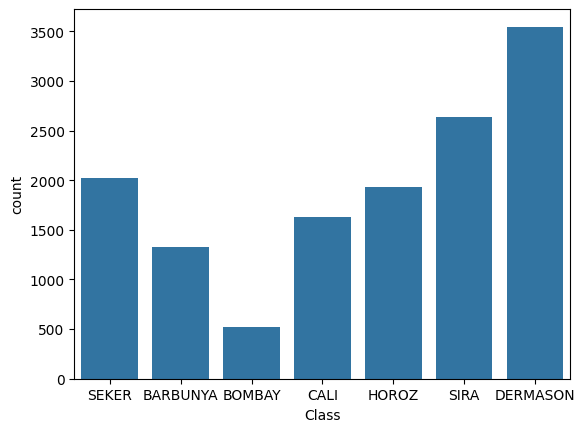

```python
import seaborn as sns
count = dataset['Class'].value_counts()
_ = sns.countplot(x="Class", data=dataset)
__ = pd.DataFrame({
    "Jumlah": count
})

display(_, __)
```

### FEATURES

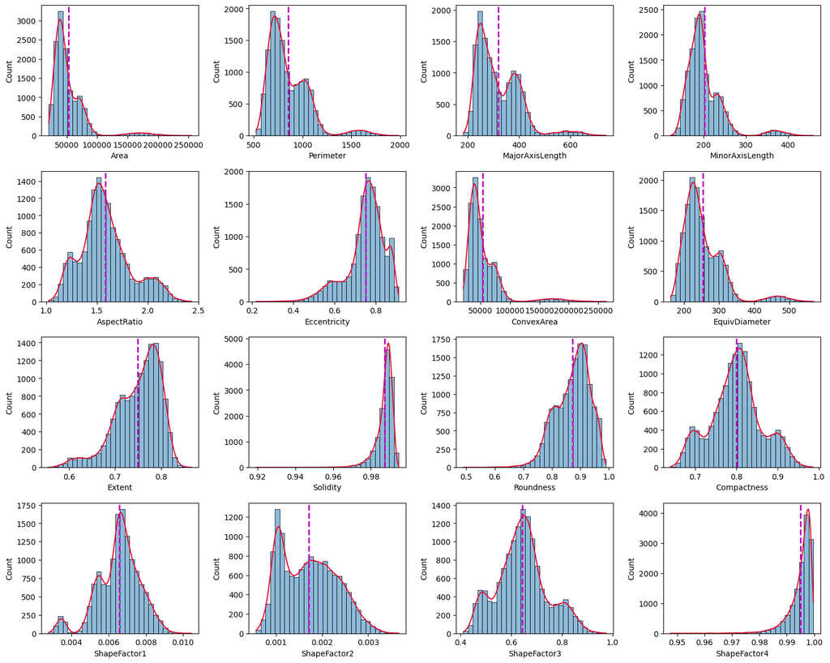

```python
import matplotlib.pyplot as plt
Numeric_cols = dataset.drop(columns=['Class']).columns

fig, ax = plt.subplots(4, 4, figsize=(15, 12))
for variable, subplot in zip(Numeric_cols, ax.flatten()):
    g=sns.histplot(dataset[variable],bins=30, kde=True, ax=subplot)
    g.lines[0].set_color('crimson')
    g.axvline(x=dataset[variable].mean(), color='m', label='Mean', linestyle='--', linewidth=2)
plt.tight_layout()
```

## DESKRIPTIF STATISTIK

Statistik deskriptif merupakan proses analisis statistik yang fokus kepada manejemen, penyajian, dan klasifikasi data. Dengan proses ini, data yang disajikan akan menjadi lebih menarik lebih mudah dipahami, dan mampu memberikan makna lebih bagi pengguna data.

```python
dataset.describe().round(decimals=3)
```

|  | Area | Perimeter | MajorAxisLength | MinorAxisLength | AspectRatio | Eccentricity | ConvexArea | EquivDiameter | Extent | Solidity | Roundness | Compactness | ShapeFactor1 | ShapeFactor2 | ShapeFactor3 | ShapeFactor4 |
| --- | --- | --- | --- | --- | --- | --- | --- | --- | --- | --- | --- | --- | --- | --- | --- | --- |
| count | 13611.000 | 13611.000 | 13611.000 | 13611.000 | 13611.000 | 13611.000 | 13611.000 | 13611.000 | 13611.000 | 13611.000 | 13611.000 | 13611.000 | 13611.000 | 13611.000 | 13611.000 | 13611.000 |
| mean | 53048.285 | 855.283 | 320.142 | 202.271 | 1.583 | 0.751 | 53768.200 | 253.064 | 0.750 | 0.987 | 0.873 | 0.800 | 0.007 | 0.002 | 0.644 | 0.995 |
| std | 29324.096 | 214.290 | 85.694 | 44.970 | 0.247 | 0.092 | 29774.916 | 59.177 | 0.049 | 0.005 | 0.060 | 0.062 | 0.001 | 0.001 | 0.099 | 0.004 |
| min | 20420.000 | 524.736 | 183.601 | 122.513 | 1.025 | 0.219 | 20684.000 | 161.244 | 0.555 | 0.919 | 0.490 | 0.641 | 0.003 | 0.001 | 0.410 | 0.948 |
| 25% | 36328.000 | 703.524 | 253.304 | 175.848 | 1.432 | 0.716 | 36714.500 | 215.068 | 0.719 | 0.986 | 0.832 | 0.762 | 0.006 | 0.001 | 0.581 | 0.994 |
| 50% | 44652.000 | 794.941 | 296.883 | 192.432 | 1.551 | 0.764 | 45178.000 | 238.438 | 0.760 | 0.988 | 0.883 | 0.801 | 0.007 | 0.002 | 0.642 | 0.996 |
| 75% | 61332.000 | 977.213 | 376.495 | 217.032 | 1.707 | 0.810 | 62294.000 | 279.446 | 0.787 | 0.990 | 0.917 | 0.834 | 0.007 | 0.002 | 0.696 | 0.998 |
| max | 254616.000 | 1985.370 | 738.860 | 460.198 | 2.430 | 0.911 | 263261.000 | 569.374 | 0.866 | 0.995 | 0.991 | 0.987 | 0.010 | 0.004 | 0.975 | 1.000 |

## TIPE DATA SETIAP COLUMN

| No. | Fitur | Deksripsi | Peran | Type | Nilai |
| --- | --- | --- | --- | --- | --- |
| 1 | Area (A) | Luas Dry Bean dalam jumlah piksel di dalam batasannya. | Fitur | Integer | Numerik |
| 2 | Perimeter (P) | Keliling Dry Bean yang didefinisikan sebagai panjang batasnya. | Fitur | Real | Numerik |
| 4 | MajorAxisLength (L) | oanjang dari ujung ke ujung garis terpanjang yang dapat digambar dari sebuah Dry Bean. | Fitur | Real | Numerik |
| 3 | MinorAxisLength (I) | Panjang garis terpanjang yang dapat digambar dari Dry Bean secara tegak lurus terhadap sumbu utama. | Fitur | Real | Numerik |
| 5 | Aspect Ratio (K) | Perbandingan antara MajorAxisLength dan MinorAxisLength. | Fitur | Real | Numerik |
| 6 | Eccentricity (Ec) | Eksentrisitas dari elips yang memiliki momen yang sama dengan wilayah Dry Bean. | Fitur | Real | Numerik |
| 7 | Convex Area (C) | Jumlah piksel dalam poligon cembung terkecil yang dapat memuat area biji Dry Bean. | Fitur | Integer | Numerik |
| 8 | EquivDiameter (Ed) | Diameter setara, yaitu diameter lingkaran yang memiliki luas yang sama dengan luas area Dry Bean. | Fitur | Real | Numerik |
| 9 | Extent (Ex) | Luas adalah rasio area kotak pembatas suatu objek terhadap area objek sebenarnya. Dalam konteks Dry Bean, ini berarti rasiopiksel dalam kotak pembatas (persegi panjang terkecil yang dapat memuat selur… | Fitur | Real | Numerik |
| 10 | Solidity (S) | juga dikenal sebagai **konveksitas**, adalah rasio antara luas suatu objek dengan luas hull konveksnya. Hull konveks adalah bentuk cembung terkecil yang dapat sepenuhnya memuat objek tersebut. Untuk *… | Fitur | Real | Numerik |
| 11 | Roundess (R) | mengukur kebulatan suatu objek. Ini kadang-kadang direpresentasikan sebagai rasio antara luas objek dengan luas lingkaran yang memiliki keliling yang sama. Ed/L | Fitur | Real | Numerik |
| 12 | Compactness (CO) | mengukur kebulatan suatu objek. Ini kadang-kadang direpresentasikan sebagai rasio antara luas objek dengan luas lingkaran yang memiliki keliling yang sama. | Fitur | Real | Numerik |
| 13 | ShapeFactor1 | L/d | Fitur | Real | Numerik |
| 14 | ShapeFactor2 | l/d | Fitur | Real | Numerik |
| 15 | ShapeFactor3 | 4A/(L^2 * pi) | Fitur | Real | Numerik |
| 16 | ShapeFactor4 | 4A/(L* l * pi) | Fitur | Real | Numerik |
| 17 | Class | BARBUNYA, SIRA, HOROZ, DERMASON, CALI, BOMBAY, and SEKER. | Target | Kategorical | Nominal |

## IDENTIFIKASI KUALITAS DATA

Setelah memahami karakteristik dasar dataset, langkah selanjutnya adalah mengidentifikasi kualitas data, termasuk:

1) Pemeriksaan Missing Value 2) Pemeriksaan Outlier

### PEMERIKSAAN MISSING VALUE

Langkah pertama untuk mengidentifikasi kualitas data salah satunya dengan pemeriksaan missing values. Pemeriksaan missing values sangat penting karena nilai yang hilang dapat mempengaruhi analisis dan model yang dibangun. Mengidentifikasi dan menangani missing values adalah langkah krusial dalam proses pembersihan data. Berikut adalah kode untuk memeriksa missing values dalam dataset:

```python
def check_missing_value(data:pd.DataFrame) -> pd.DataFrame or str:
    if isinstance(data, pd.DataFrame) is False:
        return print("Data yang di input bukan dataframe")
    else:
        is_missing = data.isnull().values.any()
        total_missing = data.isnull().sum().sum()
        df = {
            'Missing Value?' : [is_missing],
            'Total' : [total_missing]
        }
        return pd.DataFrame(df, index=['Result'])

check_missing_value(dataset)
```

|  | Missing Value? | Total |
| --- | --- | --- |
| Result | False | 0 |

Pada Pemeriksaan diatas tidak ditemukannya adanya missing value pada data Dry bean

### PEMERIKSAAN OUTLIER

Deteksi outlier adalah metode untuk mengidentifikasi titik-titik data yang dianggap sebagai outlier atau anomali. Outlier adalah nilai yang secara signifikan berbeda dari sebagian besar data lainnya dalam sebuah dataset. Mengidentifikasi outliers bermanfaat untuk meningkatkan akurasi analisis dan model prediktif, pada kali akan menggunakan euclidian distance

Pada Kasus dataset kali ini kita akan menghapus hanya 1 nilai saja dikarenakan anomaly score yang terlalu tinggi sehingga kemungkinan besar data itu mengalami error saat ektraksi fitur. kita tidak melakukan penghapus terhadap nilai yang "dianggap outlier" dikarenakan hal itu tidak diperlukan, data yang beranomaly score tinggi sebetulnya hanyalah variasi dari Dry Bean tersebut layaknya manusia yang membunyai berat badan berlebih dan ada juga yang kekurangan. pengapusan outlier juga membuat ruang lingkup belajar model lebih sedikit sehingga rawan mengalami overfitting

[figure not shown]

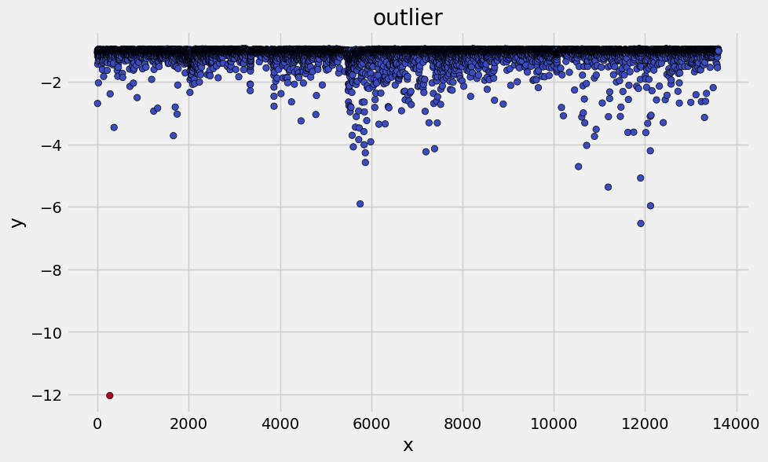

```python
import matplotlib.pyplot as plt
from sklearn.neighbors import LocalOutlierFactor
import numpy as np

def make_plot_scatter(x:list, y:list, x_title:str, y_title:str, title:str, outlier:bool=False,outlier_value = None):
    if len(x) == len(y) is False:
        return print('Jumlah Data di X dan Y tidak sama!')
    else:
        plt.style.use('fivethirtyeight')
        plt.figure(figsize=(10,6))
        plt.title(title)
        plt.xlabel(x_title)
        plt.ylabel(y_title)
        if outlier:
            plt.scatter(x, y, c=(outlier_value == -1), cmap='coolwarm', edgecolors='k')
            return plt.show()
        else:
            plt.scatter(x, y)
            plt.legend()
            return plt.show()

def get_outlier(data:pd.DataFrame, n_neighbors:int = 20,contamination:float=0.040) -> pd.DataFrame:
    data = data.select_dtypes(include='number')
    lof = LocalOutlierFactor(n_neighbors=n_neighbors, contamination=contamination, metric='euclidean')
    outlier = lof.fit_predict(data)
    outlier = pd.DataFrame(outlier)
    return outlier

def get_anomaly_scores(data:pd.DataFrame,n_neighbors:int = 20,contamination:float=0.040):
    data = data.select_dtypes(include='number')
    lof = LocalOutlierFactor(n_neighbors=n_neighbors, contamination=contamination, metric='euclidean')
    lof.fit_predict(data)
    return pd.DataFrame(lof.negative_outlier_factor_)

dataset_anomaly_scores = get_anomaly_scores(dataset, 20, 0.00001)
outlier = get_outlier(dataset, 20, 0.00001)
y = dataset_anomaly_scores
X = np.arange(len(dataset))


make_plot_scatter(X, y, 'x', 'y', 'outlier', True, outlier)
```

# PREPROCESSING DATA

## PENGHAPUS OUTLIER

Kode di bawah digunakan untuk menghapus baris-baris yang dianggap sebagai outlier dari sebuah dataset menggunakan prediksi dari metode LOF.

```python
def delete_outlier(data:pd.DataFrame, outlier_name:str):
    clean_data = data[data[outlier_name] != -1].reset_index(drop=True)
    clean_data = clean_data.drop(columns=[outlier_name])
    return clean_data

dataset['Outlier'] = outlier
print ('Jumlah baris sebelum penghapusan outlier: %d' % (len(dataset)))
display(dataset)
dataset_clean = delete_outlier(dataset, 'Outlier')
print('Jumlah baris setelah penghapusan outlier: %d' % (len(dataset_clean)))
display(dataset_clean)
```

```
Jumlah baris sebelum penghapusan outlier: 13611
```

|  | Area | Perimeter | MajorAxisLength | MinorAxisLength | AspectRatio | Eccentricity | ConvexArea | EquivDiameter | Extent | Solidity | Roundness | Compactness | ShapeFactor1 | ShapeFactor2 | ShapeFactor3 | ShapeFactor4 | Class | Outlier |
| --- | --- | --- | --- | --- | --- | --- | --- | --- | --- | --- | --- | --- | --- | --- | --- | --- | --- | --- |
| 0 | 28395 | 610.291 | 208.178117 | 173.888747 | 1.197191 | 0.549812 | 28715 | 190.141097 | 0.763923 | 0.988856 | 0.958027 | 0.913358 | 0.007332 | 0.003147 | 0.834222 | 0.998724 | SEKER | 1 |
| 1 | 28734 | 638.018 | 200.524796 | 182.734419 | 1.097356 | 0.411785 | 29172 | 191.272751 | 0.783968 | 0.984986 | 0.887034 | 0.953861 | 0.006979 | 0.003564 | 0.909851 | 0.998430 | SEKER | 1 |
| 2 | 29380 | 624.110 | 212.826130 | 175.931143 | 1.209713 | 0.562727 | 29690 | 193.410904 | 0.778113 | 0.989559 | 0.947849 | 0.908774 | 0.007244 | 0.003048 | 0.825871 | 0.999066 | SEKER | 1 |
| 3 | 30008 | 645.884 | 210.557999 | 182.516516 | 1.153638 | 0.498616 | 30724 | 195.467062 | 0.782681 | 0.976696 | 0.903936 | 0.928329 | 0.007017 | 0.003215 | 0.861794 | 0.994199 | SEKER | 1 |
| 4 | 30140 | 620.134 | 201.847882 | 190.279279 | 1.060798 | 0.333680 | 30417 | 195.896503 | 0.773098 | 0.990893 | 0.984877 | 0.970516 | 0.006697 | 0.003665 | 0.941900 | 0.999166 | SEKER | 1 |
| ... | ... | ... | ... | ... | ... | ... | ... | ... | ... | ... | ... | ... | ... | ... | ... | ... | ... | ... |
| 13606 | 42097 | 759.696 | 288.721612 | 185.944705 | 1.552728 | 0.765002 | 42508 | 231.515799 | 0.714574 | 0.990331 | 0.916603 | 0.801865 | 0.006858 | 0.001749 | 0.642988 | 0.998385 | DERMASON | 1 |
| 13607 | 42101 | 757.499 | 281.576392 | 190.713136 | 1.476439 | 0.735702 | 42494 | 231.526798 | 0.799943 | 0.990752 | 0.922015 | 0.822252 | 0.006688 | 0.001886 | 0.676099 | 0.998219 | DERMASON | 1 |
| 13608 | 42139 | 759.321 | 281.539928 | 191.187979 | 1.472582 | 0.734065 | 42569 | 231.631261 | 0.729932 | 0.989899 | 0.918424 | 0.822730 | 0.006681 | 0.001888 | 0.676884 | 0.996767 | DERMASON | 1 |
| 13609 | 42147 | 763.779 | 283.382636 | 190.275731 | 1.489326 | 0.741055 | 42667 | 231.653247 | 0.705389 | 0.987813 | 0.907906 | 0.817457 | 0.006724 | 0.001852 | 0.668237 | 0.995222 | DERMASON | 1 |
| 13610 | 42159 | 772.237 | 295.142741 | 182.204716 | 1.619841 | 0.786693 | 42600 | 231.686223 | 0.788962 | 0.989648 | 0.888380 | 0.784997 | 0.007001 | 0.001640 | 0.616221 | 0.998180 | DERMASON | 1 |

13611 rows × 18 columns

```
Jumlah baris setelah penghapusan outlier: 13610
```

|  | Area | Perimeter | MajorAxisLength | MinorAxisLength | AspectRatio | Eccentricity | ConvexArea | EquivDiameter | Extent | Solidity | Roundness | Compactness | ShapeFactor1 | ShapeFactor2 | ShapeFactor3 | ShapeFactor4 | Class |
| --- | --- | --- | --- | --- | --- | --- | --- | --- | --- | --- | --- | --- | --- | --- | --- | --- | --- |
| 0 | 28395 | 610.291 | 208.178117 | 173.888747 | 1.197191 | 0.549812 | 28715 | 190.141097 | 0.763923 | 0.988856 | 0.958027 | 0.913358 | 0.007332 | 0.003147 | 0.834222 | 0.998724 | SEKER |
| 1 | 28734 | 638.018 | 200.524796 | 182.734419 | 1.097356 | 0.411785 | 29172 | 191.272751 | 0.783968 | 0.984986 | 0.887034 | 0.953861 | 0.006979 | 0.003564 | 0.909851 | 0.998430 | SEKER |
| 2 | 29380 | 624.110 | 212.826130 | 175.931143 | 1.209713 | 0.562727 | 29690 | 193.410904 | 0.778113 | 0.989559 | 0.947849 | 0.908774 | 0.007244 | 0.003048 | 0.825871 | 0.999066 | SEKER |
| 3 | 30008 | 645.884 | 210.557999 | 182.516516 | 1.153638 | 0.498616 | 30724 | 195.467062 | 0.782681 | 0.976696 | 0.903936 | 0.928329 | 0.007017 | 0.003215 | 0.861794 | 0.994199 | SEKER |
| 4 | 30140 | 620.134 | 201.847882 | 190.279279 | 1.060798 | 0.333680 | 30417 | 195.896503 | 0.773098 | 0.990893 | 0.984877 | 0.970516 | 0.006697 | 0.003665 | 0.941900 | 0.999166 | SEKER |
| ... | ... | ... | ... | ... | ... | ... | ... | ... | ... | ... | ... | ... | ... | ... | ... | ... | ... |
| 13605 | 42097 | 759.696 | 288.721612 | 185.944705 | 1.552728 | 0.765002 | 42508 | 231.515799 | 0.714574 | 0.990331 | 0.916603 | 0.801865 | 0.006858 | 0.001749 | 0.642988 | 0.998385 | DERMASON |
| 13606 | 42101 | 757.499 | 281.576392 | 190.713136 | 1.476439 | 0.735702 | 42494 | 231.526798 | 0.799943 | 0.990752 | 0.922015 | 0.822252 | 0.006688 | 0.001886 | 0.676099 | 0.998219 | DERMASON |
| 13607 | 42139 | 759.321 | 281.539928 | 191.187979 | 1.472582 | 0.734065 | 42569 | 231.631261 | 0.729932 | 0.989899 | 0.918424 | 0.822730 | 0.006681 | 0.001888 | 0.676884 | 0.996767 | DERMASON |
| 13608 | 42147 | 763.779 | 283.382636 | 190.275731 | 1.489326 | 0.741055 | 42667 | 231.653247 | 0.705389 | 0.987813 | 0.907906 | 0.817457 | 0.006724 | 0.001852 | 0.668237 | 0.995222 | DERMASON |
| 13609 | 42159 | 772.237 | 295.142741 | 182.204716 | 1.619841 | 0.786693 | 42600 | 231.686223 | 0.788962 | 0.989648 | 0.888380 | 0.784997 | 0.007001 | 0.001640 | 0.616221 | 0.998180 | DERMASON |

13610 rows × 17 columns

```python
dataset = dataset_clean
```

## MEMISAHKAN ANTARA FITUR DENGAN TARGET

```python
X = dataset_clean.drop(['Class'], axis=1)
y = dataset_clean[['Class']]

display('Dataset Fitur', X)
display('Dataset Class', y)
```

```
'Dataset Fitur'
```

|  | Area | Perimeter | MajorAxisLength | MinorAxisLength | AspectRatio | Eccentricity | ConvexArea | EquivDiameter | Extent | Solidity | Roundness | Compactness | ShapeFactor1 | ShapeFactor2 | ShapeFactor3 | ShapeFactor4 |
| --- | --- | --- | --- | --- | --- | --- | --- | --- | --- | --- | --- | --- | --- | --- | --- | --- |
| 0 | 28395 | 610.291 | 208.178117 | 173.888747 | 1.197191 | 0.549812 | 28715 | 190.141097 | 0.763923 | 0.988856 | 0.958027 | 0.913358 | 0.007332 | 0.003147 | 0.834222 | 0.998724 |
| 1 | 28734 | 638.018 | 200.524796 | 182.734419 | 1.097356 | 0.411785 | 29172 | 191.272751 | 0.783968 | 0.984986 | 0.887034 | 0.953861 | 0.006979 | 0.003564 | 0.909851 | 0.998430 |
| 2 | 29380 | 624.110 | 212.826130 | 175.931143 | 1.209713 | 0.562727 | 29690 | 193.410904 | 0.778113 | 0.989559 | 0.947849 | 0.908774 | 0.007244 | 0.003048 | 0.825871 | 0.999066 |
| 3 | 30008 | 645.884 | 210.557999 | 182.516516 | 1.153638 | 0.498616 | 30724 | 195.467062 | 0.782681 | 0.976696 | 0.903936 | 0.928329 | 0.007017 | 0.003215 | 0.861794 | 0.994199 |
| 4 | 30140 | 620.134 | 201.847882 | 190.279279 | 1.060798 | 0.333680 | 30417 | 195.896503 | 0.773098 | 0.990893 | 0.984877 | 0.970516 | 0.006697 | 0.003665 | 0.941900 | 0.999166 |
| ... | ... | ... | ... | ... | ... | ... | ... | ... | ... | ... | ... | ... | ... | ... | ... | ... |
| 13605 | 42097 | 759.696 | 288.721612 | 185.944705 | 1.552728 | 0.765002 | 42508 | 231.515799 | 0.714574 | 0.990331 | 0.916603 | 0.801865 | 0.006858 | 0.001749 | 0.642988 | 0.998385 |
| 13606 | 42101 | 757.499 | 281.576392 | 190.713136 | 1.476439 | 0.735702 | 42494 | 231.526798 | 0.799943 | 0.990752 | 0.922015 | 0.822252 | 0.006688 | 0.001886 | 0.676099 | 0.998219 |
| 13607 | 42139 | 759.321 | 281.539928 | 191.187979 | 1.472582 | 0.734065 | 42569 | 231.631261 | 0.729932 | 0.989899 | 0.918424 | 0.822730 | 0.006681 | 0.001888 | 0.676884 | 0.996767 |
| 13608 | 42147 | 763.779 | 283.382636 | 190.275731 | 1.489326 | 0.741055 | 42667 | 231.653247 | 0.705389 | 0.987813 | 0.907906 | 0.817457 | 0.006724 | 0.001852 | 0.668237 | 0.995222 |
| 13609 | 42159 | 772.237 | 295.142741 | 182.204716 | 1.619841 | 0.786693 | 42600 | 231.686223 | 0.788962 | 0.989648 | 0.888380 | 0.784997 | 0.007001 | 0.001640 | 0.616221 | 0.998180 |

13610 rows × 16 columns

```
'Dataset Class'
```

|  | Class |
| --- | --- |
| 0 | SEKER |
| 1 | SEKER |
| 2 | SEKER |
| 3 | SEKER |
| 4 | SEKER |
| ... | ... |
| 13605 | DERMASON |
| 13606 | DERMASON |
| 13607 | DERMASON |
| 13608 | DERMASON |
| 13609 | DERMASON |

13610 rows × 1 columns

## TRANSFORMASI SCALING DATA

Metode Scaling data sangat berguna disaat kita berhadapan dengan data fitur yang bersifat conitnue seperti data set Dry Bean yang kita kerjakan dan sangat berguna jika diterapkan di model seperti K - Nearest Neighbors (KNN). dan kita akan membandingkan akurasi

### METODE STANDARISASI DATA

```python
from sklearn.preprocessing import StandardScaler
scaler_std = StandardScaler()
scaler_dump = scaler_std.fit(X)
X_std = scaler_dump.transform(X)
X_std = pd.DataFrame(X_std, columns=X.columns)
display(X_std)
```

|  | Area | Perimeter | MajorAxisLength | MinorAxisLength | AspectRatio | Eccentricity | ConvexArea | EquivDiameter | Extent | Solidity | Roundness | Compactness | ShapeFactor1 | ShapeFactor2 | ShapeFactor3 | ShapeFactor4 |
| --- | --- | --- | --- | --- | --- | --- | --- | --- | --- | --- | --- | --- | --- | --- | --- | --- |
| 0 | -0.840775 | -1.143292 | -1.306628 | -0.631168 | -1.565068 | -2.185687 | -0.841467 | -1.063374 | 0.289027 | 0.369422 | 1.424233 | 1.839073 | 0.680829 | 2.402146 | 1.925673 | 0.841189 |
| 1 | -0.829214 | -1.013901 | -1.395940 | -0.434466 | -1.969791 | -3.685961 | -0.826119 | -1.044250 | 0.697410 | -0.467621 | 0.230891 | 2.495384 | 0.368015 | 3.100849 | 2.689625 | 0.773666 |
| 2 | -0.807184 | -1.078804 | -1.252388 | -0.585751 | -1.514307 | -2.045307 | -0.808721 | -1.008118 | 0.578130 | 0.521409 | 1.253155 | 1.764802 | 0.603173 | 2.235069 | 1.841309 | 0.919912 |
| 3 | -0.785768 | -0.977194 | -1.278856 | -0.439311 | -1.741630 | -2.742161 | -0.773994 | -0.973372 | 0.671193 | -2.260452 | 0.515012 | 2.081664 | 0.401766 | 2.515045 | 2.204190 | -0.199641 |
| 4 | -0.781267 | -1.097358 | -1.380500 | -0.266689 | -2.117996 | -4.534925 | -0.784304 | -0.966115 | 0.475957 | 0.810014 | 1.875559 | 2.765256 | 0.118321 | 3.270933 | 3.013374 | 0.942895 |
| ... | ... | ... | ... | ... | ... | ... | ... | ... | ... | ... | ... | ... | ... | ... | ... | ... |
| 13605 | -0.373508 | -0.446080 | -0.366716 | -0.363078 | -0.123748 | 0.153306 | -0.378220 | -0.364194 | -0.716330 | 0.688467 | 0.727930 | 0.032451 | 0.261474 | 0.055666 | -0.006069 | 0.763296 |
| 13606 | -0.373371 | -0.456333 | -0.450098 | -0.257042 | -0.433017 | -0.165168 | -0.378690 | -0.364008 | 1.022861 | 0.779387 | 0.818905 | 0.362802 | 0.110436 | 0.285147 | 0.328398 | 0.724977 |
| 13607 | -0.372075 | -0.447830 | -0.450523 | -0.246482 | -0.448656 | -0.182966 | -0.376172 | -0.362242 | -0.403443 | 0.594936 | 0.758539 | 0.370540 | 0.104322 | 0.289236 | 0.336333 | 0.391135 |
| 13608 | -0.371802 | -0.427027 | -0.429019 | -0.266768 | -0.380775 | -0.106989 | -0.372880 | -0.361871 | -0.903456 | 0.143767 | 0.581746 | 0.285108 | 0.141958 | 0.228407 | 0.248982 | 0.035797 |
| 13609 | -0.371393 | -0.387557 | -0.291783 | -0.446245 | 0.148323 | 0.389073 | -0.375130 | -0.361314 | 0.799159 | 0.540682 | 0.253528 | -0.240876 | 0.387560 | -0.127734 | -0.276455 | 0.716000 |

13610 rows × 16 columns

```python
X_std.describe().round(decimals=3)
```

|  | Area | Perimeter | MajorAxisLength | MinorAxisLength | AspectRatio | Eccentricity | ConvexArea | EquivDiameter | Extent | Solidity | Roundness | Compactness | ShapeFactor1 | ShapeFactor2 | ShapeFactor3 | ShapeFactor4 |
| --- | --- | --- | --- | --- | --- | --- | --- | --- | --- | --- | --- | --- | --- | --- | --- | --- |
| count | 13610.000 | 13610.000 | 13610.000 | 13610.000 | 13610.000 | 13610.000 | 13610.000 | 13610.000 | 13610.000 | 13610.000 | 13610.000 | 13610.000 | 13610.000 | 13610.000 | 13610.000 | 13610.000 |
| mean | 0.000 | -0.000 | -0.000 | -0.000 | 0.000 | -0.000 | -0.000 | 0.000 | -0.000 | -0.000 | -0.000 | 0.000 | -0.000 | 0.000 | 0.000 | 0.000 |
| std | 1.000 | 1.000 | 1.000 | 1.000 | 1.000 | 1.000 | 1.000 | 1.000 | 1.000 | 1.000 | 1.000 | 1.000 | 1.000 | 1.000 | 1.000 | 1.000 |
| min | -1.113 | -1.543 | -1.593 | -1.774 | -2.264 | -5.782 | -1.111 | -1.552 | -3.961 | -9.427 | -6.449 | -2.581 | -3.356 | -1.933 | -2.356 | -10.368 |
| 25% | -0.570 | -0.708 | -0.780 | -0.588 | -0.612 | -0.380 | -0.573 | -0.642 | -0.634 | -0.319 | -0.692 | -0.606 | -0.588 | -0.944 | -0.629 | -0.314 |
| 50% | -0.286 | -0.282 | -0.271 | -0.219 | -0.130 | 0.147 | -0.288 | -0.247 | 0.206 | 0.246 | 0.166 | 0.023 | 0.072 | -0.038 | -0.016 | 0.303 |
| 75% | 0.282 | 0.569 | 0.658 | 0.328 | 0.502 | 0.647 | 0.286 | 0.446 | 0.756 | 0.620 | 0.732 | 0.558 | 0.627 | 0.762 | 0.529 | 0.648 |
| max | 6.874 | 5.274 | 4.886 | 5.736 | 3.434 | 1.745 | 7.036 | 5.345 | 2.373 | 1.628 | 1.973 | 3.037 | 3.447 | 3.271 | 3.345 | 1.073 |

### METODE NORMALISASI DATA

```python
from sklearn.preprocessing import MinMaxScaler
scaler_minmax = MinMaxScaler()
scaler_minmax.fit(X)
X_minmax = scaler_minmax.transform(X)
X_minmax = pd.DataFrame(X_minmax, columns=X.columns)
display(X_minmax)
```

|  | Area | Perimeter | MajorAxisLength | MinorAxisLength | AspectRatio | Eccentricity | ConvexArea | EquivDiameter | Extent | Solidity | Roundness | Compactness | ShapeFactor1 | ShapeFactor2 | ShapeFactor3 | ShapeFactor4 |
| --- | --- | --- | --- | --- | --- | --- | --- | --- | --- | --- | --- | --- | --- | --- | --- | --- |
| 0 | 0.034053 | 0.058574 | 0.044262 | 0.152142 | 0.122612 | 0.477797 | 0.033107 | 0.070804 | 0.671024 | 0.886117 | 0.934823 | 0.786733 | 0.593432 | 0.833049 | 0.750996 | 0.979723 |
| 1 | 0.035500 | 0.077557 | 0.030479 | 0.178337 | 0.051577 | 0.278472 | 0.034991 | 0.073577 | 0.735504 | 0.810402 | 0.793138 | 0.903549 | 0.547447 | 0.967316 | 0.884987 | 0.973821 |
| 2 | 0.038259 | 0.068035 | 0.052633 | 0.158190 | 0.131521 | 0.496448 | 0.037126 | 0.078816 | 0.716671 | 0.899865 | 0.914511 | 0.773514 | 0.582016 | 0.800942 | 0.736200 | 0.986603 |
| 3 | 0.040940 | 0.082942 | 0.048548 | 0.177691 | 0.091623 | 0.403864 | 0.041389 | 0.083854 | 0.731365 | 0.648232 | 0.826871 | 0.829912 | 0.552408 | 0.854744 | 0.799846 | 0.888753 |
| 4 | 0.041504 | 0.065313 | 0.032862 | 0.200679 | 0.025565 | 0.165680 | 0.040123 | 0.084906 | 0.700538 | 0.925971 | 0.988408 | 0.951583 | 0.510741 | 1.000000 | 0.941770 | 0.988612 |
| ... | ... | ... | ... | ... | ... | ... | ... | ... | ... | ... | ... | ... | ... | ... | ... | ... |
| 13605 | 0.092559 | 0.160862 | 0.189318 | 0.187843 | 0.375584 | 0.788553 | 0.089967 | 0.172180 | 0.512286 | 0.914976 | 0.852151 | 0.465175 | 0.531785 | 0.382135 | 0.412185 | 0.972915 |
| 13606 | 0.092576 | 0.159358 | 0.176450 | 0.201964 | 0.321303 | 0.746241 | 0.089910 | 0.172207 | 0.786890 | 0.923200 | 0.862952 | 0.523974 | 0.509582 | 0.426233 | 0.470848 | 0.969566 |
| 13607 | 0.092739 | 0.160605 | 0.176384 | 0.203370 | 0.318558 | 0.743877 | 0.090219 | 0.172463 | 0.561689 | 0.906516 | 0.855785 | 0.525351 | 0.508683 | 0.427019 | 0.472240 | 0.940387 |
| 13608 | 0.092773 | 0.163657 | 0.179703 | 0.200669 | 0.330472 | 0.753971 | 0.090623 | 0.172517 | 0.482741 | 0.865705 | 0.834795 | 0.510145 | 0.514216 | 0.415330 | 0.456919 | 0.909330 |
| 13609 | 0.092824 | 0.169448 | 0.200882 | 0.176768 | 0.423337 | 0.819877 | 0.090347 | 0.172598 | 0.751569 | 0.901608 | 0.795826 | 0.416526 | 0.550320 | 0.346892 | 0.364762 | 0.968781 |

13610 rows × 16 columns

```python
X_minmax.describe().round(decimals=3)
```

|  | Area | Perimeter | MajorAxisLength | MinorAxisLength | AspectRatio | Eccentricity | ConvexArea | EquivDiameter | Extent | Solidity | Roundness | Compactness | ShapeFactor1 | ShapeFactor2 | ShapeFactor3 | ShapeFactor4 |
| --- | --- | --- | --- | --- | --- | --- | --- | --- | --- | --- | --- | --- | --- | --- | --- | --- |
| count | 13610.000 | 13610.000 | 13610.000 | 13610.000 | 13610.000 | 13610.000 | 13610.000 | 13610.000 | 13610.000 | 13610.000 | 13610.000 | 13610.000 | 13610.000 | 13610.000 | 13610.000 | 13610.000 |
| mean | 0.139 | 0.226 | 0.246 | 0.236 | 0.397 | 0.768 | 0.136 | 0.225 | 0.625 | 0.853 | 0.766 | 0.459 | 0.493 | 0.371 | 0.413 | 0.906 |
| std | 0.125 | 0.147 | 0.154 | 0.133 | 0.176 | 0.133 | 0.123 | 0.145 | 0.158 | 0.090 | 0.119 | 0.178 | 0.147 | 0.192 | 0.175 | 0.087 |
| min | 0.000 | 0.000 | 0.000 | 0.000 | 0.000 | 0.000 | 0.000 | 0.000 | 0.000 | 0.000 | 0.000 | 0.000 | 0.000 | 0.000 | 0.000 | 0.000 |
| 25% | 0.068 | 0.122 | 0.126 | 0.158 | 0.290 | 0.718 | 0.066 | 0.132 | 0.525 | 0.824 | 0.684 | 0.352 | 0.407 | 0.190 | 0.303 | 0.879 |
| 50% | 0.103 | 0.185 | 0.204 | 0.207 | 0.374 | 0.788 | 0.101 | 0.189 | 0.658 | 0.875 | 0.785 | 0.463 | 0.504 | 0.364 | 0.410 | 0.933 |
| 75% | 0.175 | 0.310 | 0.347 | 0.280 | 0.485 | 0.854 | 0.172 | 0.290 | 0.745 | 0.909 | 0.853 | 0.559 | 0.586 | 0.518 | 0.506 | 0.963 |
| max | 1.000 | 1.000 | 1.000 | 1.000 | 1.000 | 1.000 | 1.000 | 1.000 | 1.000 | 1.000 | 1.000 | 1.000 | 1.000 | 1.000 | 1.000 | 1.000 |

# MODELLING DATA

Setelah melakukan preprocessing data untuk membersihkan dan menyiapkan dataset, langkah selanjutnya adalah melakukan modelling data menggunakan algoritma Naive Bayes, KNN, TREE, SVC . pada bagian ini kita akan menghitung akurasi setiap model dengan data yang di standarisasi dan di normalisasi dan membandingkan mana yang terbaik

## SPLIT DATA MENJADI TRAINING DAN TESTING

Kita akan membagi data training sebanyak 80% dan testing 20%

### Data (NORMALISASI)

```python
from sklearn.model_selection import train_test_split
from sklearn.preprocessing import LabelEncoder

X_train_minmax, X_test_minmax, y_train_minmax, y_test_minmax = train_test_split(X_minmax,y ,
                          random_state=0,
                          train_size=0.8, shuffle=True)


display('X_train_minmax', X_train_minmax)
display('X_test_minmax', X_test_minmax)
display('y_train_minmax', y_train_minmax)
display('y_test_minmax', y_test_minmax)
```

```
'X_train_minmax'
```

|  | Area | Perimeter | MajorAxisLength | MinorAxisLength | AspectRatio | Eccentricity | ConvexArea | EquivDiameter | Extent | Solidity | Roundness | Compactness | ShapeFactor1 | ShapeFactor2 | ShapeFactor3 | ShapeFactor4 |
| --- | --- | --- | --- | --- | --- | --- | --- | --- | --- | --- | --- | --- | --- | --- | --- | --- |
| 8818 | 0.104566 | 0.187777 | 0.214897 | 0.199552 | 0.405800 | 0.808932 | 0.102363 | 0.190820 | 0.461682 | 0.843661 | 0.787033 | 0.429170 | 0.517035 | 0.339077 | 0.376990 | 0.884795 |
| 2301 | 0.175870 | 0.327114 | 0.313706 | 0.287651 | 0.429795 | 0.823758 | 0.173322 | 0.291159 | 0.787407 | 0.754836 | 0.560141 | 0.410166 | 0.394818 | 0.251849 | 0.358637 | 0.968016 |
| 5659 | 0.096902 | 0.204529 | 0.274829 | 0.126751 | 0.717812 | 0.941275 | 0.095203 | 0.178991 | 0.145288 | 0.807408 | 0.617363 | 0.162411 | 0.654225 | 0.183940 | 0.133437 | 0.757693 |
| 12063 | 0.053028 | 0.099795 | 0.100840 | 0.157673 | 0.240740 | 0.665258 | 0.051555 | 0.105936 | 0.525366 | 0.897239 | 0.854768 | 0.613934 | 0.588805 | 0.588056 | 0.563450 | 0.863013 |
| 6157 | 0.130485 | 0.249181 | 0.318134 | 0.173581 | 0.685936 | 0.932108 | 0.127786 | 0.229161 | 0.407484 | 0.838024 | 0.641663 | 0.192182 | 0.558907 | 0.169709 | 0.159116 | 0.899801 |
| ... | ... | ... | ... | ... | ... | ... | ... | ... | ... | ... | ... | ... | ... | ... | ... | ... |
| 13123 | 0.074352 | 0.140581 | 0.163419 | 0.158601 | 0.379433 | 0.791264 | 0.072443 | 0.142685 | 0.713250 | 0.887311 | 0.802976 | 0.459846 | 0.582988 | 0.408970 | 0.406941 | 0.950123 |
| 3264 | 0.279574 | 0.443946 | 0.385363 | 0.455212 | 0.294872 | 0.722434 | 0.276147 | 0.415210 | 0.789923 | 0.707833 | 0.587992 | 0.551502 | 0.241183 | 0.258844 | 0.498819 | 0.921462 |
| 9845 | 0.131176 | 0.225967 | 0.242851 | 0.245175 | 0.374418 | 0.787725 | 0.127935 | 0.230152 | 0.453711 | 0.885869 | 0.778197 | 0.463590 | 0.449465 | 0.328782 | 0.410624 | 0.924256 |
| 10799 | 0.031888 | 0.064394 | 0.081404 | 0.097670 | 0.317748 | 0.743174 | 0.030988 | 0.066626 | 0.652540 | 0.886999 | 0.849443 | 0.527800 | 0.707177 | 0.568932 | 0.474717 | 0.966243 |
| 2732 | 0.213300 | 0.371376 | 0.380627 | 0.309850 | 0.507944 | 0.865182 | 0.209047 | 0.338357 | 0.762432 | 0.824634 | 0.572560 | 0.338423 | 0.369354 | 0.186457 | 0.290735 | 0.981346 |

10888 rows × 16 columns

```
'X_test_minmax'
```

|  | Area | Perimeter | MajorAxisLength | MinorAxisLength | AspectRatio | Eccentricity | ConvexArea | EquivDiameter | Extent | Solidity | Roundness | Compactness | ShapeFactor1 | ShapeFactor2 | ShapeFactor3 | ShapeFactor4 |
| --- | --- | --- | --- | --- | --- | --- | --- | --- | --- | --- | --- | --- | --- | --- | --- | --- |
| 8627 | 0.100830 | 0.190380 | 0.209700 | 0.195080 | 0.403997 | 0.807772 | 0.098678 | 0.185084 | 0.504840 | 0.846772 | 0.736315 | 0.428567 | 0.525962 | 0.343810 | 0.376405 | 0.842484 |
| 11034 | 0.036388 | 0.078106 | 0.101322 | 0.093257 | 0.378977 | 0.790944 | 0.035799 | 0.075270 | 0.742444 | 0.820356 | 0.801473 | 0.460696 | 0.718041 | 0.494412 | 0.407777 | 0.956629 |
| 13204 | 0.076304 | 0.133608 | 0.156405 | 0.171744 | 0.336823 | 0.759176 | 0.073878 | 0.145923 | 0.658095 | 0.944500 | 0.875823 | 0.507168 | 0.558453 | 0.442319 | 0.453931 | 0.978431 |
| 7578 | 0.073588 | 0.137489 | 0.159107 | 0.161080 | 0.364557 | 0.780591 | 0.071462 | 0.141411 | 0.830635 | 0.916312 | 0.816682 | 0.474649 | 0.579193 | 0.421846 | 0.421538 | 0.935703 |
| 1961 | 0.127235 | 0.203913 | 0.182384 | 0.302885 | 0.172470 | 0.570870 | 0.123816 | 0.224484 | 0.780062 | 0.910884 | 0.884161 | 0.712554 | 0.377248 | 0.518606 | 0.668928 | 0.974782 |
| ... | ... | ... | ... | ... | ... | ... | ... | ... | ... | ... | ... | ... | ... | ... | ... | ... |
| 6366 | 0.138777 | 0.257631 | 0.325833 | 0.186541 | 0.668946 | 0.926934 | 0.135858 | 0.240940 | 0.277723 | 0.841902 | 0.657605 | 0.206297 | 0.535640 | 0.170411 | 0.171422 | 0.934103 |
| 12280 | 0.056572 | 0.105054 | 0.115900 | 0.150145 | 0.289325 | 0.717128 | 0.054890 | 0.112228 | 0.545923 | 0.914244 | 0.858760 | 0.560793 | 0.597733 | 0.530309 | 0.508332 | 0.967553 |
| 9915 | 0.135241 | 0.252000 | 0.279159 | 0.224033 | 0.486566 | 0.854779 | 0.133174 | 0.235945 | 0.369314 | 0.773336 | 0.661813 | 0.346125 | 0.485072 | 0.250788 | 0.297920 | 0.773684 |
| 1343 | 0.089259 | 0.143108 | 0.140782 | 0.233136 | 0.196329 | 0.607369 | 0.086278 | 0.166948 | 0.756553 | 0.968261 | 0.947723 | 0.679745 | 0.463512 | 0.561010 | 0.633378 | 0.981192 |
| 2158 | 0.156066 | 0.324228 | 0.250501 | 0.306271 | 0.287019 | 0.714888 | 0.154120 | 0.264823 | 0.716280 | 0.733556 | 0.456439 | 0.559634 | 0.376151 | 0.364820 | 0.507144 | 0.902876 |

2722 rows × 16 columns

```
'y_train_minmax'
```

|  | Class |
| --- | --- |
| 8818 | SIRA |
| 2301 | BARBUNYA |
| 5659 | HOROZ |
| 12063 | DERMASON |
| 6157 | HOROZ |
| ... | ... |
| 13123 | DERMASON |
| 3264 | BARBUNYA |
| 9845 | SIRA |
| 10799 | DERMASON |
| 2732 | BARBUNYA |

10888 rows × 1 columns

```
'y_test_minmax'
```

|  | Class |
| --- | --- |
| 8627 | SIRA |
| 11034 | DERMASON |
| 13204 | DERMASON |
| 7578 | SIRA |
| 1961 | SEKER |
| ... | ... |
| 6366 | HOROZ |
| 12280 | DERMASON |
| 9915 | SIRA |
| 1343 | SEKER |
| 2158 | BARBUNYA |

2722 rows × 1 columns

| Class | Jumlah |
| --- | --- |
| DERMASON | 3546 |
| SIRA | 2636 |
| SEKER | 2026 |
| HOROZ | 1928 |
| CALI | 1630 |
| BARBUNYA | 1322 |
| BOMBAY | 522 |

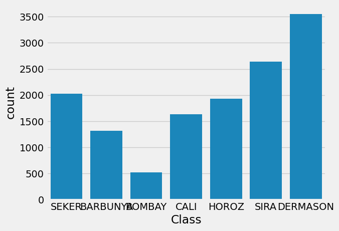

```python
count = dataset['Class'].value_counts()
_ = sns.countplot(x="Class", data=dataset)
__ = pd.DataFrame({
    "Jumlah": count
})

display(_, __)
```

### DATA (STANDARISASI)

```python
X_train_std, X_test_std, y_train_std, y_test_std = train_test_split(X_std,y ,
                          random_state=0,
                          train_size=0.8, shuffle=True)

display('X_train_std', X_train_std)
display('X_test_std', X_test_std)
display('y_train_std', y_train_std)
display('y_test_std', y_test_std)
```

```
'X_train_std'
```

|  | Area | Perimeter | MajorAxisLength | MinorAxisLength | AspectRatio | Eccentricity | ConvexArea | EquivDiameter | Extent | Solidity | Roundness | Compactness | ShapeFactor1 | ShapeFactor2 | ShapeFactor3 | ShapeFactor4 |
| --- | --- | --- | --- | --- | --- | --- | --- | --- | --- | --- | --- | --- | --- | --- | --- | --- |
| 8818 | -0.277612 | -0.262623 | -0.200968 | -0.275160 | 0.048408 | 0.306690 | -0.277228 | -0.235638 | -1.036834 | -0.099943 | 0.179475 | -0.169839 | 0.161136 | -0.168400 | -0.206735 | -0.244919 |
| 2301 | 0.291859 | 0.687125 | 0.439277 | 0.386395 | 0.185120 | 0.418283 | 0.300882 | 0.456388 | 1.026139 | -1.081923 | -1.731535 | -0.276608 | -0.670259 | -0.622321 | -0.311377 | 0.707247 |
| 5659 | -0.338826 | -0.148436 | 0.187365 | -0.821828 | 1.826110 | 1.302808 | -0.335566 | -0.317218 | -3.040699 | -0.500718 | -1.249582 | -1.668577 | 1.094381 | -0.975705 | -1.595359 | -1.699165 |
| 12063 | -0.689225 | -0.862321 | -0.940022 | -0.589636 | -0.892027 | -0.774709 | -0.691171 | -0.821071 | -0.633488 | 0.492376 | 0.749973 | 0.868228 | 0.649358 | 1.127247 | 0.856375 | -0.494144 |
| 6157 | -0.070612 | 0.155919 | 0.467969 | -0.470177 | 1.644491 | 1.233807 | -0.070105 | 0.028797 | -1.380092 | -0.162254 | -1.044915 | -1.501314 | 0.445973 | -1.049764 | -1.448953 | -0.073231 |
| ... | ... | ... | ... | ... | ... | ... | ... | ... | ... | ... | ... | ... | ... | ... | ... | ... |
| 13123 | -0.518919 | -0.584314 | -0.534530 | -0.582666 | -0.101818 | 0.173706 | -0.520993 | -0.567622 | 0.556465 | 0.382627 | 0.313751 | 0.002510 | 0.609788 | 0.195312 | -0.035969 | 0.502528 |
| 3264 | 1.120097 | 1.483469 | 0.903591 | 1.644641 | -0.583612 | -0.344361 | 1.138609 | 1.311956 | 1.042068 | -1.601548 | -1.496958 | 0.517465 | -1.715377 | -0.585920 | 0.487875 | 0.174605 |
| 9845 | -0.065088 | -0.002311 | -0.019841 | 0.067437 | -0.130392 | 0.147073 | -0.068896 | 0.035632 | -1.087315 | 0.366685 | 0.105052 | 0.023547 | -0.298516 | -0.221974 | -0.014968 | 0.206567 |
| 10799 | -0.858065 | -1.103621 | -1.065963 | -1.040203 | -0.453275 | -0.188257 | -0.858730 | -1.092189 | 0.171961 | 0.379176 | 0.705118 | 0.384301 | 1.454592 | 1.027728 | 0.350457 | 0.686963 |
| 2732 | 0.590798 | 0.988820 | 0.872904 | 0.553088 | 0.630376 | 0.730072 | 0.591935 | 0.781908 | 0.867955 | -0.310290 | -1.626930 | -0.679687 | -0.843477 | -0.962612 | -0.698520 | 0.859764 |

10888 rows × 16 columns

```
'X_test_std'
```

|  | Area | Perimeter | MajorAxisLength | MinorAxisLength | AspectRatio | Eccentricity | ConvexArea | EquivDiameter | Extent | Solidity | Roundness | Compactness | ShapeFactor1 | ShapeFactor2 | ShapeFactor3 | ShapeFactor4 |
| --- | --- | --- | --- | --- | --- | --- | --- | --- | --- | --- | --- | --- | --- | --- | --- | --- |
| 8627 | -0.307452 | -0.244880 | -0.234648 | -0.308738 | 0.038136 | 0.297956 | -0.307254 | -0.275197 | -0.763494 | -0.065545 | -0.247704 | -0.173228 | 0.221859 | -0.143771 | -0.210070 | -0.729027 |
| 11034 | -0.822121 | -1.010154 | -0.936898 | -1.073341 | -0.104420 | 0.171299 | -0.819536 | -1.032572 | 0.741363 | -0.357581 | 0.301092 | 0.007284 | 1.528494 | 0.639935 | -0.031205 | 0.576961 |
| 13204 | -0.503334 | -0.631848 | -0.579979 | -0.483973 | -0.344592 | -0.067808 | -0.509305 | -0.545288 | 0.207141 | 1.014860 | 0.927312 | 0.268381 | 0.442885 | 0.368855 | 0.231944 | 0.826406 |
| 7578 | -0.525023 | -0.605393 | -0.562472 | -0.564050 | -0.186579 | 0.093373 | -0.528986 | -0.576406 | 1.299919 | 0.703240 | 0.429190 | 0.085678 | 0.583972 | 0.262317 | 0.047253 | 0.337536 |
| 1961 | -0.096564 | -0.152636 | -0.411645 | 0.500789 | -1.281000 | -1.485148 | -0.102448 | -0.003458 | 0.979616 | 0.643227 | 0.997535 | 1.422307 | -0.789778 | 0.765837 | 1.457759 | 0.784658 |
| ... | ... | ... | ... | ... | ... | ... | ... | ... | ... | ... | ... | ... | ... | ... | ... | ... |
| 6366 | -0.004386 | 0.213518 | 0.517858 | -0.372855 | 1.547692 | 1.194865 | -0.004345 | 0.110034 | -2.201926 | -0.119382 | -0.910642 | -1.422016 | 0.287694 | -1.046110 | -1.378791 | 0.319229 |
| 12280 | -0.660920 | -0.826472 | -0.842438 | -0.646164 | -0.615214 | -0.384299 | -0.664001 | -0.777675 | -0.503294 | 0.680379 | 0.783595 | 0.569663 | 0.710090 | 0.826738 | 0.542113 | 0.701947 |
| 9915 | -0.032623 | 0.175136 | 0.215426 | -0.091322 | 0.508577 | 0.651773 | -0.026209 | 0.075583 | -1.621839 | -0.877400 | -0.875199 | -0.636413 | -0.056298 | -0.627840 | -0.657557 | -1.516194 |
| 1343 | -0.399868 | -0.567090 | -0.681214 | -0.022967 | -1.145062 | -1.210425 | -0.408279 | -0.400280 | 0.830720 | 1.277543 | 1.532888 | 1.237975 | -0.202963 | 0.986503 | 1.255068 | 0.857996 |
| 2158 | 0.133693 | 0.667456 | 0.029731 | 0.526213 | -0.628351 | -0.401156 | 0.144440 | 0.274750 | 0.575654 | -1.317177 | -2.604966 | 0.563156 | -0.797238 | -0.034440 | 0.535340 | -0.038054 |

2722 rows × 16 columns

```
'y_train_std'
```

|  | Class |
| --- | --- |
| 8818 | SIRA |
| 2301 | BARBUNYA |
| 5659 | HOROZ |
| 12063 | DERMASON |
| 6157 | HOROZ |
| ... | ... |
| 13123 | DERMASON |
| 3264 | BARBUNYA |
| 9845 | SIRA |
| 10799 | DERMASON |
| 2732 | BARBUNYA |

10888 rows × 1 columns

```
'y_test_std'
```

|  | Class |
| --- | --- |
| 8627 | SIRA |
| 11034 | DERMASON |
| 13204 | DERMASON |
| 7578 | SIRA |
| 1961 | SEKER |
| ... | ... |
| 6366 | HOROZ |
| 12280 | DERMASON |
| 9915 | SIRA |
| 1343 | SEKER |
| 2158 | BARBUNYA |

2722 rows × 1 columns

## MEMBUAT MODEL DAN CHECK AKURASI

### Naive Bayes

Naive Bayes, atau kadang disebut Naïve Bayes Classifier, adalah algoritma machine learning probabilistik yang digunakan dalam berbagai macam tugas klasifikasi. Naive Bayes Classifier adalah sebuah algoritma klasifikasi yang didasarkan pada teorema Bayes dengan asumsi sederhana (naive) bahwa setiap fitur dalam dataset adalah independen satu sama lain. berikut adalah rumus nya:

$$ P(H \mid A) = \frac{P(A \mid H) \cdot P(H)}{P(A)} $$

Di mana:

𝑃(𝐻∣𝐴) adalah probabilitas posterior dari kelas 𝐻 jika diberikan fitur 𝐴 𝑃(𝐴∣𝐻) adalah probabilitas likelihood dari fitur 𝐴 jika kelasnya adalah 𝐻 𝑃(𝐻) adalah probabilitas prior dari kelas 𝐻 𝑃(𝐴) adalah probabilitas prior dari fitur 𝐴

MENGGUNAKAN DATA YANG DI NORMALISASI

```python
from sklearn.naive_bayes import GaussianNB, CategoricalNB, BernoulliNB, MultinomialNB,ComplementNB
from sklearn.metrics import accuracy_score, confusion_matrix, classification_report
def get_accuracy(method, X_train, y_train, X_test, y_test):
    le = LabelEncoder()
    y_train = le.fit_transform(y_train)
    y_test = le.fit_transform(y_test)
    acc = []
    index =  []
    for clf in method:
        c = clf
        c.fit(X_train, y_train.ravel())
        y_pred = c.predict(X_test)
        accucary = accuracy_score(y_test, y_pred)
        acc.append(accucary)
        index.append(str(clf).replace('(', '').replace(')', ''))

    df = pd.DataFrame({
        'Model': index,
        'Accuracy': acc

    })
    return df

method = [
    GaussianNB(),
    BernoulliNB(),
    MultinomialNB(),
    ComplementNB()
]
minmax = get_accuracy(method, X_train_minmax, y_train_minmax, X_test_minmax, y_test_minmax)
display(minmax)
```

|  | Model | Accuracy |
| --- | --- | --- |
| 0 | GaussianNB | 0.897134 |
| 1 | BernoulliNB | 0.275900 |
| 2 | MultinomialNB | 0.537472 |
| 3 | ComplementNB | 0.603968 |

MENGGUNAKAN DATA YANG DI STANDARISASI

```python
method = [
    GaussianNB(),
    BernoulliNB(),
]

naive_std = get_accuracy(method, X_train_std, y_train_std, X_test_std, y_test_std)
display(naive_std)
```

|  | Model | Accuracy |
| --- | --- | --- |
| 0 | GaussianNB | 0.897134 |
| 1 | BernoulliNB | 0.721528 |

Maka dapat disumpulkan metoode naive bayes memiliki akurasi yang paling tinggi dibandingkan yang lainnya serta memiliki nilai akurasi yang persis antara data normalisasi dan standarisasi

### KNN

Algoritma (K-NN) adalah algoritma pembelajaran mesin yang serbaguna dan banyak digunakan terutama digunakan karena kesederhanaan dan kemudahan implementasinya. Algoritma ini tidak memerlukan asumsi apa pun tentang distribusi data yang mendasarinya. Algoritma ini juga dapat menangani data numerik dan kategorikal, menjadikannya pilihan yang fleksibel untuk berbagai jenis kumpulan data dalam tugas klasifikasi dan regresi. Algoritma ini adalah metode nonparametrik yang membuat prediksi berdasarkan kesamaan titik data dalam kumpulan data tertentu. K-NN kurang sensitif terhadap outlier dibandingkan dengan algoritma lainnya.

Algoritma K-NN bekerja dengan menemukan K tetangga terdekat ke titik data tertentu berdasarkan metrik jarak, seperti jarak Euclidean. Kelas atau nilai titik data kemudian ditentukan oleh suara mayoritas atau rata-rata K tetangga. Pendekatan ini memungkinkan algoritma untuk beradaptasi dengan pola yang berbeda dan membuat prediksi berdasarkan struktur lokal data.

Pada percobaan kita kali ini kita akan menjalani algoritma ini sebanyak 47x yang dimana setiap iterasi akan meningkatkan n_neighbors nya

MENGGUNAKAN DATA YANG DI NORMALISASI

```python
from sklearn.neighbors import KNeighborsClassifier

method = []
for i in range(3, 50, 1):
    method.append(KNeighborsClassifier(n_neighbors=i))

KNN_MINMAX = get_accuracy(method, X_train_minmax, y_train_minmax, X_test_minmax, y_test_minmax)
display(KNN_MINMAX)
```

|  | Model | Accuracy |
| --- | --- | --- |
| 0 | KNeighborsClassifiern_neighbors=3 | 0.920647 |
| 1 | KNeighborsClassifiern_neighbors=4 | 0.919177 |
| 2 | KNeighborsClassifier | 0.922116 |
| 3 | KNeighborsClassifiern_neighbors=6 | 0.918075 |
| 4 | KNeighborsClassifiern_neighbors=7 | 0.922116 |
| 5 | KNeighborsClassifiern_neighbors=8 | 0.921381 |
| 6 | KNeighborsClassifiern_neighbors=9 | 0.922851 |
| 7 | KNeighborsClassifiern_neighbors=10 | 0.918810 |
| 8 | KNeighborsClassifiern_neighbors=11 | 0.921014 |
| 9 | KNeighborsClassifiern_neighbors=12 | 0.919544 |
| 10 | KNeighborsClassifiern_neighbors=13 | 0.922483 |
| 11 | KNeighborsClassifiern_neighbors=14 | 0.922116 |
| 12 | KNeighborsClassifiern_neighbors=15 | 0.924688 |
| 13 | KNeighborsClassifiern_neighbors=16 | 0.923953 |
| 14 | KNeighborsClassifiern_neighbors=17 | 0.923586 |
| 15 | KNeighborsClassifiern_neighbors=18 | 0.926157 |
| 16 | KNeighborsClassifiern_neighbors=19 | 0.926157 |
| 17 | KNeighborsClassifiern_neighbors=20 | 0.926157 |
| 18 | KNeighborsClassifiern_neighbors=21 | 0.925055 |
| 19 | KNeighborsClassifiern_neighbors=22 | 0.926525 |
| 20 | KNeighborsClassifiern_neighbors=23 | 0.926157 |
| 21 | KNeighborsClassifiern_neighbors=24 | 0.927259 |
| 22 | KNeighborsClassifiern_neighbors=25 | 0.926157 |
| 23 | KNeighborsClassifiern_neighbors=26 | 0.927259 |
| 24 | KNeighborsClassifiern_neighbors=27 | 0.926525 |
| 25 | KNeighborsClassifiern_neighbors=28 | 0.925422 |
| 26 | KNeighborsClassifiern_neighbors=29 | 0.927627 |
| 27 | KNeighborsClassifiern_neighbors=30 | 0.926525 |
| 28 | KNeighborsClassifiern_neighbors=31 | 0.925790 |
| 29 | KNeighborsClassifiern_neighbors=32 | 0.926157 |
| 30 | KNeighborsClassifiern_neighbors=33 | 0.927627 |
| 31 | KNeighborsClassifiern_neighbors=34 | 0.927259 |
| 32 | KNeighborsClassifiern_neighbors=35 | 0.927994 |
| 33 | KNeighborsClassifiern_neighbors=36 | 0.928729 |
| 34 | KNeighborsClassifiern_neighbors=37 | 0.929096 |
| 35 | KNeighborsClassifiern_neighbors=38 | 0.929096 |
| 36 | KNeighborsClassifiern_neighbors=39 | 0.927994 |
| 37 | KNeighborsClassifiern_neighbors=40 | 0.926525 |
| 38 | KNeighborsClassifiern_neighbors=41 | 0.928361 |
| 39 | KNeighborsClassifiern_neighbors=42 | 0.926157 |
| 40 | KNeighborsClassifiern_neighbors=43 | 0.926525 |
| 41 | KNeighborsClassifiern_neighbors=44 | 0.925790 |
| 42 | KNeighborsClassifiern_neighbors=45 | 0.927259 |
| 43 | KNeighborsClassifiern_neighbors=46 | 0.926892 |
| 44 | KNeighborsClassifiern_neighbors=47 | 0.926157 |
| 45 | KNeighborsClassifiern_neighbors=48 | 0.924688 |
| 46 | KNeighborsClassifiern_neighbors=49 | 0.925055 |

```
No artists with labels found to put in legend.  Note that artists whose label start with an underscore are ignored when legend() is called with no argument.
```

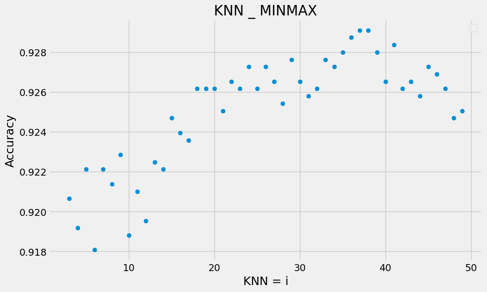

```python
_Y = KNN_MINMAX[['Accuracy']]
_X = np.arange(3, 50, 1)

make_plot_scatter(_X, _Y, 'KNN = i', 'Accuracy', 'KNN _ MINMAX', False)
```

```python
from sklearn.neighbors import KNeighborsClassifier
method = []
for i in range(3, 50, 1):
    method.append(KNeighborsClassifier(n_neighbors=i))

KNN_STD = get_accuracy(method, X_train_std, y_train_std, X_test_std, y_test_std)
display(KNN_STD)
```

|  | Model | Accuracy |
| --- | --- | --- |
| 0 | KNeighborsClassifiern_neighbors=3 | 0.926157 |
| 1 | KNeighborsClassifiern_neighbors=4 | 0.921014 |
| 2 | KNeighborsClassifier | 0.923953 |
| 3 | KNeighborsClassifiern_neighbors=6 | 0.920647 |
| 4 | KNeighborsClassifiern_neighbors=7 | 0.922116 |
| 5 | KNeighborsClassifiern_neighbors=8 | 0.922483 |
| 6 | KNeighborsClassifiern_neighbors=9 | 0.926892 |
| 7 | KNeighborsClassifiern_neighbors=10 | 0.925790 |
| 8 | KNeighborsClassifiern_neighbors=11 | 0.926892 |
| 9 | KNeighborsClassifiern_neighbors=12 | 0.923953 |
| 10 | KNeighborsClassifiern_neighbors=13 | 0.928361 |
| 11 | KNeighborsClassifiern_neighbors=14 | 0.923586 |
| 12 | KNeighborsClassifiern_neighbors=15 | 0.927627 |
| 13 | KNeighborsClassifiern_neighbors=16 | 0.925055 |
| 14 | KNeighborsClassifiern_neighbors=17 | 0.926525 |
| 15 | KNeighborsClassifiern_neighbors=18 | 0.927259 |
| 16 | KNeighborsClassifiern_neighbors=19 | 0.927994 |
| 17 | KNeighborsClassifiern_neighbors=20 | 0.927627 |
| 18 | KNeighborsClassifiern_neighbors=21 | 0.931668 |
| 19 | KNeighborsClassifiern_neighbors=22 | 0.928361 |
| 20 | KNeighborsClassifiern_neighbors=23 | 0.929464 |
| 21 | KNeighborsClassifiern_neighbors=24 | 0.927627 |
| 22 | KNeighborsClassifiern_neighbors=25 | 0.928361 |
| 23 | KNeighborsClassifiern_neighbors=26 | 0.929096 |
| 24 | KNeighborsClassifiern_neighbors=27 | 0.930933 |
| 25 | KNeighborsClassifiern_neighbors=28 | 0.928361 |
| 26 | KNeighborsClassifiern_neighbors=29 | 0.929464 |
| 27 | KNeighborsClassifiern_neighbors=30 | 0.927259 |
| 28 | KNeighborsClassifiern_neighbors=31 | 0.928729 |
| 29 | KNeighborsClassifiern_neighbors=32 | 0.926525 |
| 30 | KNeighborsClassifiern_neighbors=33 | 0.927259 |
| 31 | KNeighborsClassifiern_neighbors=34 | 0.927259 |
| 32 | KNeighborsClassifiern_neighbors=35 | 0.926525 |
| 33 | KNeighborsClassifiern_neighbors=36 | 0.926892 |
| 34 | KNeighborsClassifiern_neighbors=37 | 0.926525 |
| 35 | KNeighborsClassifiern_neighbors=38 | 0.926892 |
| 36 | KNeighborsClassifiern_neighbors=39 | 0.926892 |
| 37 | KNeighborsClassifiern_neighbors=40 | 0.926525 |
| 38 | KNeighborsClassifiern_neighbors=41 | 0.927259 |
| 39 | KNeighborsClassifiern_neighbors=42 | 0.927627 |
| 40 | KNeighborsClassifiern_neighbors=43 | 0.926157 |
| 41 | KNeighborsClassifiern_neighbors=44 | 0.925790 |
| 42 | KNeighborsClassifiern_neighbors=45 | 0.926157 |
| 43 | KNeighborsClassifiern_neighbors=46 | 0.926157 |
| 44 | KNeighborsClassifiern_neighbors=47 | 0.925790 |
| 45 | KNeighborsClassifiern_neighbors=48 | 0.925422 |
| 46 | KNeighborsClassifiern_neighbors=49 | 0.925790 |

```
No artists with labels found to put in legend.  Note that artists whose label start with an underscore are ignored when legend() is called with no argument.
```

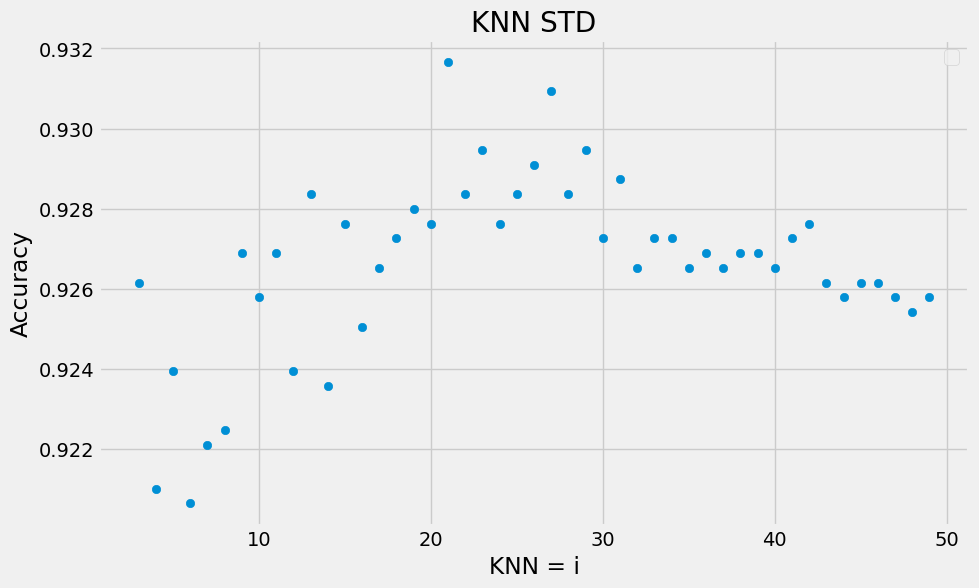

```python
_Y = KNN_STD[['Accuracy']]
_X = np.arange(3, 50, 1)

make_plot_scatter(_X, _Y, 'KNN = i', 'Accuracy', 'KNN STD', False)
```

Bisa dilihat terhadap perbandingan persebaran data antara data normlisasi dan standarisasi, data dengan standarisasi memiliki aakurasi yang lebih baik dibandingan yang di normalisasi

### TREE

#### Apa itu Decision Tree?

Decision tree adalah struktur mirip diagram alir yang digunakan untuk membuat keputusan atau prediksi. Struktur ini terdiri dari node yang mewakili keputusan atau pengujian pada atribut, cabang yang mewakili hasil dari keputusan ini, dan leaf nodes yang mewakili hasil akhir atau prediksi. Setiap node internal sesuai dengan pengujian pada atribut, setiap cabang sesuai dengan hasil pengujian, dan setiap leaf node sesuai dengan label kelas atau nilai kontinu.

#### Struktur Decision Tree

- Root Node: Mewakili seluruh dataset dan keputusan awal yang harus dibuat.
- Internal Nodes: Mewakili keputusan atau pengujian pada atribut. Setiap node internal memiliki satu atau - lebih cabang.
- Branches: Mewakili hasil dari keputusan atau pengujian, mengarah ke node lain.
- Leaf Nodes: Mewakili keputusan atau prediksi akhir. Tidak ada pembagian lebih lanjut pada node ini.

#### Bagimana Decision Tree bekerja?

Proses pembuatan decision tree melibatkan:

- Memilih Atribut Terbaik: Menggunakan metrik seperti Gini impurity, entropy, atau information gain, atribut terbaik untuk membagi data dipilih.
- Membagi Dataset: Dataset dibagi menjadi subset berdasarkan atribut yang dipilih.
- Mengulangi Proses: Proses diulangi secara rekursif untuk setiap subset, menciptakan node internal atau leaf node baru hingga kriteria penghentian terpenuhi (misalnya, semua instance dalam satu node termasuk dalam kelas yang sama atau kedalaman yang telah ditentukan tercapai).

#### Metrics untuk membagi

- Gini Impurity: Mengukur kemungkinan klasifikasi yang salah dari instance baru jika diklasifikasikan secara acak menurut distribusi kelas dalam dataset.
- Entropy: Mengukur jumlah ketidakpastian atau impurity dalam dataset
- Information Gain: Mengukur pengurangan entropy atau Gini impurity setelah dataset dibagi berdasarkan atribut.

#### Keuntungan Decision Trees

- Kesederhanaan dan Interpretabilitas: Decision trees mudah dipahami dan diinterpretasikan. Representasi visualnya sangat mirip dengan proses pengambilan keputusan manusia.
- Fleksibilitas: Dapat digunakan untuk tugas klasifikasi dan regresi.
- Tidak Memerlukan Scaling Fitur: Decision trees tidak memerlukan normalisasi atau scaling data.
- Menangani Hubungan Non-linear: Mampu menangkap hubungan non-linear antara fitur dan variabel target.

#### Kekurangan Decision Trees

- Overfitting: Decision trees dapat dengan mudah overfit data pelatihan, terutama jika mereka dalam dengan banyak node.
- Ketidakstabilan: Variasi kecil dalam data dapat menghasilkan tree yang sangat berbeda.
- Bias terhadap Fitur dengan Level Lebih Banyak: Fitur dengan level lebih banyak dapat mendominasi struktur tree.

PERHITUNGAN DATA MENGGUNAKAN DATA NORMALISASI

```python
from sklearn.tree import DecisionTreeClassifier
method = [DecisionTreeClassifier(max_depth=i) for i in range(2, 50, 1)]
DTree_MINMAX = get_accuracy(method, X_train_minmax, y_train_minmax, X_test_minmax, y_test_minmax)
DTree_MINMAX
```

|  | Model | Accuracy |
| --- | --- | --- |
| 0 | DecisionTreeClassifiermax_depth=2 | 0.660176 |
| 1 | DecisionTreeClassifiermax_depth=3 | 0.789860 |
| 2 | DecisionTreeClassifiermax_depth=4 | 0.828435 |
| 3 | DecisionTreeClassifiermax_depth=5 | 0.879868 |
| 4 | DecisionTreeClassifiermax_depth=6 | 0.903747 |
| 5 | DecisionTreeClassifiermax_depth=7 | 0.904849 |
| 6 | DecisionTreeClassifiermax_depth=8 | 0.907788 |
| 7 | DecisionTreeClassifiermax_depth=9 | 0.913666 |
| 8 | DecisionTreeClassifiermax_depth=10 | 0.908156 |
| 9 | DecisionTreeClassifiermax_depth=11 | 0.907421 |
| 10 | DecisionTreeClassifiermax_depth=12 | 0.899706 |
| 11 | DecisionTreeClassifiermax_depth=13 | 0.899339 |
| 12 | DecisionTreeClassifiermax_depth=14 | 0.897134 |
| 13 | DecisionTreeClassifiermax_depth=15 | 0.893828 |
| 14 | DecisionTreeClassifiermax_depth=16 | 0.893461 |
| 15 | DecisionTreeClassifiermax_depth=17 | 0.895298 |
| 16 | DecisionTreeClassifiermax_depth=18 | 0.890889 |
| 17 | DecisionTreeClassifiermax_depth=19 | 0.890154 |
| 18 | DecisionTreeClassifiermax_depth=20 | 0.887583 |
| 19 | DecisionTreeClassifiermax_depth=21 | 0.890154 |
| 20 | DecisionTreeClassifiermax_depth=22 | 0.887950 |
| 21 | DecisionTreeClassifiermax_depth=23 | 0.892726 |
| 22 | DecisionTreeClassifiermax_depth=24 | 0.892359 |
| 23 | DecisionTreeClassifiermax_depth=25 | 0.888317 |
| 24 | DecisionTreeClassifiermax_depth=26 | 0.885746 |
| 25 | DecisionTreeClassifiermax_depth=27 | 0.889052 |
| 26 | DecisionTreeClassifiermax_depth=28 | 0.890154 |
| 27 | DecisionTreeClassifiermax_depth=29 | 0.889787 |
| 28 | DecisionTreeClassifiermax_depth=30 | 0.889787 |
| 29 | DecisionTreeClassifiermax_depth=31 | 0.887215 |
| 30 | DecisionTreeClassifiermax_depth=32 | 0.890889 |
| 31 | DecisionTreeClassifiermax_depth=33 | 0.893461 |
| 32 | DecisionTreeClassifiermax_depth=34 | 0.889052 |
| 33 | DecisionTreeClassifiermax_depth=35 | 0.888317 |
| 34 | DecisionTreeClassifiermax_depth=36 | 0.889052 |
| 35 | DecisionTreeClassifiermax_depth=37 | 0.890889 |
| 36 | DecisionTreeClassifiermax_depth=38 | 0.889052 |
| 37 | DecisionTreeClassifiermax_depth=39 | 0.890522 |
| 38 | DecisionTreeClassifiermax_depth=40 | 0.891624 |
| 39 | DecisionTreeClassifiermax_depth=41 | 0.888685 |
| 40 | DecisionTreeClassifiermax_depth=42 | 0.892359 |
| 41 | DecisionTreeClassifiermax_depth=43 | 0.891256 |
| 42 | DecisionTreeClassifiermax_depth=44 | 0.888685 |
| 43 | DecisionTreeClassifiermax_depth=45 | 0.891256 |
| 44 | DecisionTreeClassifiermax_depth=46 | 0.889787 |
| 45 | DecisionTreeClassifiermax_depth=47 | 0.889420 |
| 46 | DecisionTreeClassifiermax_depth=48 | 0.892359 |
| 47 | DecisionTreeClassifiermax_depth=49 | 0.891256 |

```
No artists with labels found to put in legend.  Note that artists whose label start with an underscore are ignored when legend() is called with no argument.
```

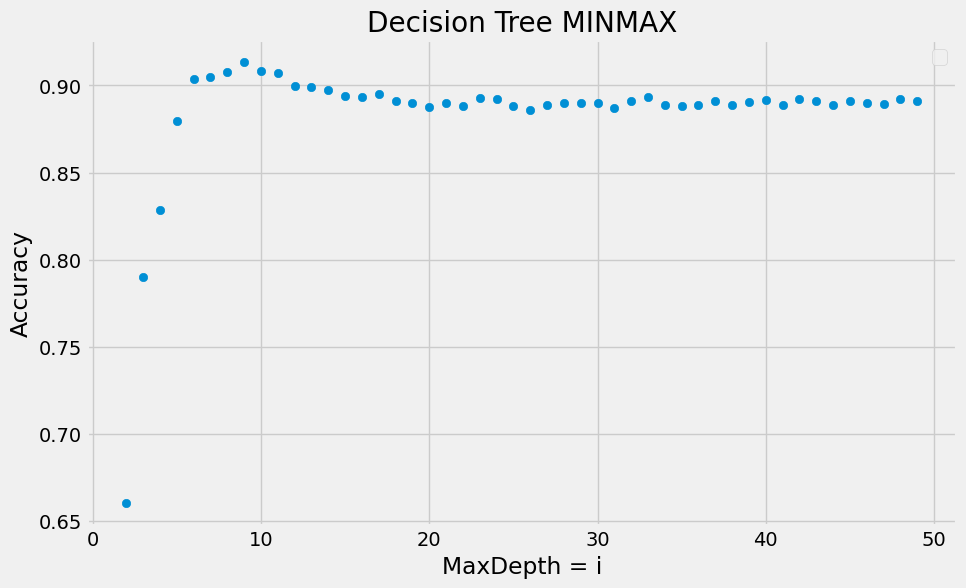

```python
_Y = DTree_MINMAX[['Accuracy']]
_X = np.arange(2, 50, 1)

make_plot_scatter(_X, _Y, 'MaxDepth = i', 'Accuracy', 'Decision Tree MINMAX', False)
```

PERHITUNGAN DATA MENGGUNAKAN DATA STANDARISASI

```python
method = [DecisionTreeClassifier(max_depth=i) for i in range(2, 50, 1)]
DTree_STD = get_accuracy(method, X_train_std, y_train_std, X_test_std, y_test_std)
DTree_STD
```

|  | Model | Accuracy |
| --- | --- | --- |
| 0 | DecisionTreeClassifiermax_depth=2 | 0.660176 |
| 1 | DecisionTreeClassifiermax_depth=3 | 0.789860 |
| 2 | DecisionTreeClassifiermax_depth=4 | 0.828435 |
| 3 | DecisionTreeClassifiermax_depth=5 | 0.879500 |
| 4 | DecisionTreeClassifiermax_depth=6 | 0.904115 |
| 5 | DecisionTreeClassifiermax_depth=7 | 0.904115 |
| 6 | DecisionTreeClassifiermax_depth=8 | 0.908891 |
| 7 | DecisionTreeClassifiermax_depth=9 | 0.914401 |
| 8 | DecisionTreeClassifiermax_depth=10 | 0.908156 |
| 9 | DecisionTreeClassifiermax_depth=11 | 0.902278 |
| 10 | DecisionTreeClassifiermax_depth=12 | 0.900073 |
| 11 | DecisionTreeClassifiermax_depth=13 | 0.901910 |
| 12 | DecisionTreeClassifiermax_depth=14 | 0.899706 |
| 13 | DecisionTreeClassifiermax_depth=15 | 0.895665 |
| 14 | DecisionTreeClassifiermax_depth=16 | 0.898237 |
| 15 | DecisionTreeClassifiermax_depth=17 | 0.896032 |
| 16 | DecisionTreeClassifiermax_depth=18 | 0.893461 |
| 17 | DecisionTreeClassifiermax_depth=19 | 0.892359 |
| 18 | DecisionTreeClassifiermax_depth=20 | 0.891256 |
| 19 | DecisionTreeClassifiermax_depth=21 | 0.889052 |
| 20 | DecisionTreeClassifiermax_depth=22 | 0.891256 |
| 21 | DecisionTreeClassifiermax_depth=23 | 0.889052 |
| 22 | DecisionTreeClassifiermax_depth=24 | 0.888685 |
| 23 | DecisionTreeClassifiermax_depth=25 | 0.887583 |
| 24 | DecisionTreeClassifiermax_depth=26 | 0.887215 |
| 25 | DecisionTreeClassifiermax_depth=27 | 0.888317 |
| 26 | DecisionTreeClassifiermax_depth=28 | 0.889787 |
| 27 | DecisionTreeClassifiermax_depth=29 | 0.888685 |
| 28 | DecisionTreeClassifiermax_depth=30 | 0.893461 |
| 29 | DecisionTreeClassifiermax_depth=31 | 0.889787 |
| 30 | DecisionTreeClassifiermax_depth=32 | 0.890154 |
| 31 | DecisionTreeClassifiermax_depth=33 | 0.885746 |
| 32 | DecisionTreeClassifiermax_depth=34 | 0.891256 |
| 33 | DecisionTreeClassifiermax_depth=35 | 0.889787 |
| 34 | DecisionTreeClassifiermax_depth=36 | 0.892726 |
| 35 | DecisionTreeClassifiermax_depth=37 | 0.892726 |
| 36 | DecisionTreeClassifiermax_depth=38 | 0.891624 |
| 37 | DecisionTreeClassifiermax_depth=39 | 0.888317 |
| 38 | DecisionTreeClassifiermax_depth=40 | 0.887950 |
| 39 | DecisionTreeClassifiermax_depth=41 | 0.888317 |
| 40 | DecisionTreeClassifiermax_depth=42 | 0.889420 |
| 41 | DecisionTreeClassifiermax_depth=43 | 0.889420 |
| 42 | DecisionTreeClassifiermax_depth=44 | 0.891991 |
| 43 | DecisionTreeClassifiermax_depth=45 | 0.887215 |
| 44 | DecisionTreeClassifiermax_depth=46 | 0.887950 |
| 45 | DecisionTreeClassifiermax_depth=47 | 0.888317 |
| 46 | DecisionTreeClassifiermax_depth=48 | 0.890522 |
| 47 | DecisionTreeClassifiermax_depth=49 | 0.890154 |

```
No artists with labels found to put in legend.  Note that artists whose label start with an underscore are ignored when legend() is called with no argument.
```

[figure not shown]

```python
_X = np.arange(2, 50, 1)
_Y = DTree_STD[['Accuracy']]
make_plot_scatter(_X, _Y, 'MaxDepth = i', 'Accuracy', 'Decision Tree STD', False)
```

Bisa disimpulkan perbandingan akurasi antara data normalisasi dan data standarisasi tidak berbeda jauh, sesuai dengan penjelasan tentang kelebihan decision tree

### SVC

#### Apa itu SVM (Support Vector Machine)?

Support Vector Machine (SVM) adalah algoritma pembelajaran mesin yang digunakan untuk klasifikasi dan regresi. SVM bekerja dengan menemukan hyperplane di ruang dimensi tinggi yang secara jelas memisahkan titik data dari kelas yang berbeda. Tujuan utama dari SVM adalah untuk menemukan hyperplane yang memiliki margin terbesar (jarak terjauh) antara titik data dari kedua kelas.

#### Bagaimana SVM Bekerja?

- Hyperplane: Dalam konteks SVM, hyperplane adalah garis atau permukaan yang memisahkan data menjadi kelas yang berbeda. Dalam dua dimensi, ini adalah garis; dalam tiga dimensi, ini adalah bidang.
- Support Vectors: Titik data yang paling dekat dengan hyperplane disebut support vectors. Mereka adalah elemen penting dari dataset karena mereka menentukan posisi dan orientasi hyperplane.
- Margin: Jarak antara hyperplane dan support vectors disebut margin. SVM mencoba memaksimalkan margin ini untuk memastikan bahwa hyperplane memisahkan kelas dengan baik.

#### Jenis-Jenis Kernel dalam SVM

Kernel adalah fungsi yang mengubah data ke dalam bentuk yang lebih tinggi dari dimensi yang membuatnya lebih mudah untuk memisahkan dengan hyperplane. Beberapa jenis kernel yang umum digunakan adalah:

- Linear Kernel: Digunakan saat data dapat dipisahkan secara linear. Fungsi kernel linear adalah: $K(x_i, x_j) = x_i \cdot x_j$
- Polynomial Kernel: Digunakan saat data tidak dapat dipisahkan secara linear. Fungsi kernel polynomial adalah: $K(x_i, x_j) = (\gamma x_i \cdot x_j + r)^d$
- Radial Basis Function (RBF): Digunakan saat data tidak dapat dipisahkan secara linear. Fungsi kernel RBF adalah: $K(x_i, x_j) = \exp(-\gamma ||x_i - x_j||^2)$
- Sigmoid Kernel: Digunakan saat data tidak dapat dipisahkan secara linear. Fungsi kernel sigmoid adalah: $K(x_i, x_j) = \tanh(\gamma x_i \cdot x_j + r)$

#### Kelebihan SVM

- Efektif dalam Dimensi Tinggi: SVM tetap efektif dalam ruang berdimensi tinggi dan bahkan dalam kasus di mana jumlah dimensi lebih besar dari jumlah sampel.
- Memori Efisien: SVM menggunakan subset dari titik pelatihan (support vectors) dalam proses keputusan, yang membuatnya memori efisien.
- Flexibilitas dengan Kernel: SVM dapat menggunakan berbagai fungsi kernel untuk memodelkan hubungan non-linear antara fitur.

#### Kekurangan SVM

- Waktu Pelatihan yang Lama: SVM bisa lambat dalam pelatihan, terutama untuk dataset yang sangat besar.
- Pemilihan Kernel dan Parameter: Memilih kernel yang tepat dan mengatur parameter SVM (seperti C dan 𝛾) dapat menjadi sulit dan memerlukan cross-validation.
- Kurang Efektif pada Dataset Besar dengan Noise: SVM kurang efektif jika terdapat banyak noise dan outliers dalam data karena mereka dapat mempengaruhi posisi hyperplane.

PERHITUNGAN MENGGUNAKAN DATA YANG DI NORMALISASI

```python
from sklearn.svm import SVC
method = [SVC(kernel='linear'),
          SVC(kernel='poly'),
          SVC(kernel='rbf'),
          SVC(kernel='sigmoid')]

SVM_MINMAX = get_accuracy(method, X_train_minmax, y_train_minmax, X_test_minmax, y_test_minmax)
SVM_MINMAX
```

|  | Model | Accuracy |
| --- | --- | --- |
| 0 | SVCkernel='linear' | 0.927627 |
| 1 | SVCkernel='poly' | 0.931668 |
| 2 | SVC | 0.929464 |
| 3 | SVCkernel='sigmoid' | 0.526819 |

PERHITUNGAN MENGGUNAKAN DATA YANG DI STANDARISASI

```python
method = [SVC(kernel='linear'),
          SVC(kernel='poly'),
          SVC(kernel='rbf'),
          SVC(kernel='sigmoid')]

SVM_STD = get_accuracy(method, X_train_std, y_train_std, X_test_std, y_test_std)
SVM_STD
```

|  | Model | Accuracy |
| --- | --- | --- |
| 0 | SVCkernel='linear' | 0.933137 |
| 1 | SVCkernel='poly' | 0.909258 |
| 2 | SVC | 0.934240 |
| 3 | SVCkernel='sigmoid' | 0.738060 |

### LIST OF ACCURACY

Lalu pada setiap hasil akurasi diatas kita akan memilih metode mana yang paling efektif dan didapatkan hasil seperti pada tabel:

```python
max_naive = naive_std.loc[[naive_std['Accuracy'].idxmax()]]
max_KNN = KNN_STD.loc[[KNN_STD['Accuracy'].idxmax()]]
max_DTree = DTree_STD.loc[[DTree_STD['Accuracy'].idxmax()]]
max_SVM = SVM_STD.loc[[SVM_STD['Accuracy'].idxmax()]]

df = pd.concat([max_naive, max_KNN, max_DTree, max_SVM], axis=0)
df.round(decimals=4)
```

|  | Model | Accuracy |
| --- | --- | --- |
| 0 | GaussianNB | 0.8971 |
| 18 | KNeighborsClassifiern_neighbors=21 | 0.9317 |
| 7 | DecisionTreeClassifiermax_depth=9 | 0.9144 |
| 2 | SVC | 0.9342 |

## ENSEMBLE LEARNING

Setelah dilakukan Pemodelan, ada banyak cara untuk meningkatkan akurasi prediksi dari model yang telah kita buat salah satunya adalah Ensemble Learning.

Apa itu Ensemble Learning?

### PENGERTIAN ENSEMBLE LEARNING

```
Ensemble learning adalah teknik yang digunakan untuk meningkatkan kinerja dan akurasi model-model pembelajaran mesin dengan menggabungkan hasil prediksi dari beberapa model atau algoritma yang berbeda.
```

```
Istilah ensemble merujuk pada konsep menggabungkan banyak elemen menjadi satu kesatuan. Konsep penggabungan berbagai pendekatan pembelajaran mesin diharapkan dapat mengatasi kelemahan individu dari masing-masing model dan menciptakan prediksi yang lebih akurat dan stabil.
```

```
Cara kerja dari metode ensemble melibatkan penggunaan beberapa model yang beragam dalam satu tim. Hasil prediksi dari masing-masing model tersebut digabungkan untuk membuat keputusan akhir.
```

```
Pada project kali ini kita akan menggunakan 3 metode dalam ensemble learning yaitu Bagging, Random Forest, dan Stakcing dan mencari metode mana yang terbaik untuk data kita.
```

## BAGGING

### PENGERTIAN METODE BAGGING

Bagging (bootstrap aggregating) merupakan metode ensemble yang melibatkan pelatihan beberapa model secara sendiri pada dataset yang diacak, dan menggabungkan prediksi mereka melalui pemungutan suara.

```
setiap model dilatih pada dataset yang diacak dari data yang diambil sampelnya,  data individual dapat dipilih lebih dari satu kali. data acak ini dikenal sebagai sampel bootstrap. Dengan melatih model pada bootstrap yang berbeda, bagging mengurangi varians dari masing-masing model. Bagging juga dapat menghindari overfitting.
```

```
Prediksi dari semua model yang diambil sampelnya kemudian digabungkan dan dibuat voting yang dimana hasil prediksi terbanyak akan di keluarkan sebagai hasil prediksi akhir
```

```
Bagging sangat efektif dalam mengurangi varians dan overfitting, membuat model lebih tangguh dan akurat, terutama dalam kasus di mana masing-masing model rentan terhadap variabilitas tinggi.
```

[figure not shown]

Dan pada percobaan kali ini kita akan melakukan proses bagging kepada setiap algortima terbaik dari setiap model yang telah kita hitung diatas. dan model terbaik antara model normal atau model bagging akan dipilih yang terbaik dan akan dimasukkan pada metode stacking yang akan kami jelaskan nanti dan semua perhitungan disin menggunakan data yang di standarisasi dikarenakan data tersebut yang memiliki akurasi paling tinggi, masing masing iterasi akan mengubah nilai n_estimatorsnya(juri) dari 3 sampai 49 dengan step 2

### Naive Bayes

```python
from sklearn.ensemble import BaggingClassifier
def Bagging(method,X_train, y_train, X_test, y_test):
    le = LabelEncoder()
    y_train = le.fit_transform(y_train)
    y_test = le.fit_transform(y_test)
    acc = []
    index = []
    for n in range(3, 50, 2):
        clf = BaggingClassifier(estimator=method, n_estimators=n, random_state=None)
        clf.fit(X_train, y_train.ravel())
        y_pred = clf.predict(X_test)
        accuracy = accuracy_score(y_pred, y_test)
        acc.append(accuracy)
        index.append(str(clf).replace('(', '').replace(')', ''))

    df = pd.DataFrame({
        'Model': index,
        'Accuracy': acc

    })
    return df

Bagging_naive = Bagging(GaussianNB(),X_train_std, y_train_std, X_test_std, y_test_std)
Bagging_naive
```

|  | Model | Accuracy |
| --- | --- | --- |
| 0 | BaggingClassifierestimator=GaussianNB, n_estim... | 0.897502 |
| 1 | BaggingClassifierestimator=GaussianNB, n_estim... | 0.896400 |
| 2 | BaggingClassifierestimator=GaussianNB, n_estim... | 0.897134 |
| 3 | BaggingClassifierestimator=GaussianNB, n_estim... | 0.895298 |
| 4 | BaggingClassifierestimator=GaussianNB, n_estim... | 0.897869 |
| 5 | BaggingClassifierestimator=GaussianNB, n_estim... | 0.897502 |
| 6 | BaggingClassifierestimator=GaussianNB, n_estim... | 0.896400 |
| 7 | BaggingClassifierestimator=GaussianNB, n_estim... | 0.896400 |
| 8 | BaggingClassifierestimator=GaussianNB, n_estim... | 0.897134 |
| 9 | BaggingClassifierestimator=GaussianNB, n_estim... | 0.897502 |
| 10 | BaggingClassifierestimator=GaussianNB, n_estim... | 0.896767 |
| 11 | BaggingClassifierestimator=GaussianNB, n_estim... | 0.896767 |
| 12 | BaggingClassifierestimator=GaussianNB, n_estim... | 0.895665 |
| 13 | BaggingClassifierestimator=GaussianNB, n_estim... | 0.897134 |
| 14 | BaggingClassifierestimator=GaussianNB, n_estim... | 0.897502 |
| 15 | BaggingClassifierestimator=GaussianNB, n_estim... | 0.897869 |
| 16 | BaggingClassifierestimator=GaussianNB, n_estim... | 0.897134 |
| 17 | BaggingClassifierestimator=GaussianNB, n_estim... | 0.896767 |
| 18 | BaggingClassifierestimator=GaussianNB, n_estim... | 0.897502 |
| 19 | BaggingClassifierestimator=GaussianNB, n_estim... | 0.897502 |
| 20 | BaggingClassifierestimator=GaussianNB, n_estim... | 0.897134 |
| 21 | BaggingClassifierestimator=GaussianNB, n_estim... | 0.896400 |
| 22 | BaggingClassifierestimator=GaussianNB, n_estim... | 0.897869 |
| 23 | BaggingClassifierestimator=GaussianNB, n_estim... | 0.897869 |

```
No artists with labels found to put in legend.  Note that artists whose label start with an underscore are ignored when legend() is called with no argument.
```

[figure not shown]

```python
_X = np.arange(3, 50, 2)
_Y = Bagging_naive[['Accuracy']]
make_plot_scatter(_X, _Y, 'Bagging_naive = i', 'Accuracy', 'Bagging Naive', False)
```

### KNN

```
'Bagging_KNN'
```

|  | Model | Accuracy |
| --- | --- | --- |
| 0 | BaggingClassifierestimator=KNeighborsClassifie... | 0.927994 |
| 1 | BaggingClassifierestimator=KNeighborsClassifie... | 0.928729 |
| 2 | BaggingClassifierestimator=KNeighborsClassifie... | 0.927627 |
| 3 | BaggingClassifierestimator=KNeighborsClassifie... | 0.927994 |
| 4 | BaggingClassifierestimator=KNeighborsClassifie... | 0.927994 |
| 5 | BaggingClassifierestimator=KNeighborsClassifie... | 0.924688 |
| 6 | BaggingClassifierestimator=KNeighborsClassifie... | 0.928361 |
| 7 | BaggingClassifierestimator=KNeighborsClassifie... | 0.927994 |
| 8 | BaggingClassifierestimator=KNeighborsClassifie... | 0.927994 |
| 9 | BaggingClassifierestimator=KNeighborsClassifie... | 0.929096 |
| 10 | BaggingClassifierestimator=KNeighborsClassifie... | 0.926892 |
| 11 | BaggingClassifierestimator=KNeighborsClassifie... | 0.927994 |
| 12 | BaggingClassifierestimator=KNeighborsClassifie... | 0.928361 |
| 13 | BaggingClassifierestimator=KNeighborsClassifie... | 0.927994 |
| 14 | BaggingClassifierestimator=KNeighborsClassifie... | 0.927259 |
| 15 | BaggingClassifierestimator=KNeighborsClassifie... | 0.930198 |
| 16 | BaggingClassifierestimator=KNeighborsClassifie... | 0.928361 |
| 17 | BaggingClassifierestimator=KNeighborsClassifie... | 0.929096 |
| 18 | BaggingClassifierestimator=KNeighborsClassifie... | 0.929096 |
| 19 | BaggingClassifierestimator=KNeighborsClassifie... | 0.925790 |
| 20 | BaggingClassifierestimator=KNeighborsClassifie... | 0.928729 |
| 21 | BaggingClassifierestimator=KNeighborsClassifie... | 0.927627 |
| 22 | BaggingClassifierestimator=KNeighborsClassifie... | 0.929096 |
| 23 | BaggingClassifierestimator=KNeighborsClassifie... | 0.929096 |

```
No artists with labels found to put in legend.  Note that artists whose label start with an underscore are ignored when legend() is called with no argument.
```

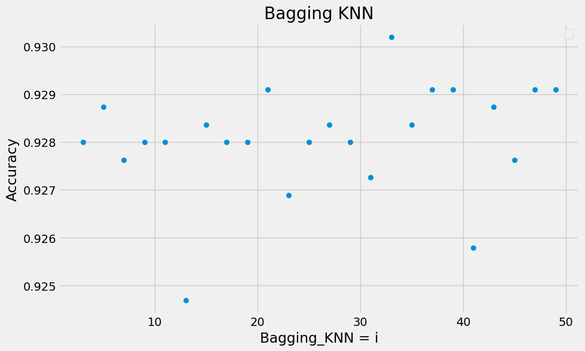

```python
Bagging_KNN = Bagging(KNeighborsClassifier(n_neighbors=21),X_train_std, y_train_std, X_test_std, y_test_std)
_X = np.arange(3, 50, 2)
_Y = Bagging_KNN[['Accuracy']]
display('Bagging_KNN', Bagging_KNN)
make_plot_scatter(_X, _Y, 'Bagging_KNN = i', 'Accuracy', 'Bagging KNN', False)
```

### TREE

```
'Bagging_tree'
```

|  | Model | Accuracy |
| --- | --- | --- |
| 0 | BaggingClassifierestimator=DecisionTreeClassif... | 0.914769 |
| 1 | BaggingClassifierestimator=DecisionTreeClassif... | 0.917708 |
| 2 | BaggingClassifierestimator=DecisionTreeClassif... | 0.926525 |
| 3 | BaggingClassifierestimator=DecisionTreeClassif... | 0.926157 |
| 4 | BaggingClassifierestimator=DecisionTreeClassif... | 0.926157 |
| 5 | BaggingClassifierestimator=DecisionTreeClassif... | 0.926892 |
| 6 | BaggingClassifierestimator=DecisionTreeClassif... | 0.924688 |
| 7 | BaggingClassifierestimator=DecisionTreeClassif... | 0.927627 |
| 8 | BaggingClassifierestimator=DecisionTreeClassif... | 0.925790 |
| 9 | BaggingClassifierestimator=DecisionTreeClassif... | 0.926892 |
| 10 | BaggingClassifierestimator=DecisionTreeClassif... | 0.928729 |
| 11 | BaggingClassifierestimator=DecisionTreeClassif... | 0.926157 |
| 12 | BaggingClassifierestimator=DecisionTreeClassif... | 0.924688 |
| 13 | BaggingClassifierestimator=DecisionTreeClassif... | 0.929464 |
| 14 | BaggingClassifierestimator=DecisionTreeClassif... | 0.929096 |
| 15 | BaggingClassifierestimator=DecisionTreeClassif... | 0.927627 |
| 16 | BaggingClassifierestimator=DecisionTreeClassif... | 0.928361 |
| 17 | BaggingClassifierestimator=DecisionTreeClassif... | 0.929831 |
| 18 | BaggingClassifierestimator=DecisionTreeClassif... | 0.928361 |
| 19 | BaggingClassifierestimator=DecisionTreeClassif... | 0.928361 |
| 20 | BaggingClassifierestimator=DecisionTreeClassif... | 0.930566 |
| 21 | BaggingClassifierestimator=DecisionTreeClassif... | 0.926892 |
| 22 | BaggingClassifierestimator=DecisionTreeClassif... | 0.929096 |
| 23 | BaggingClassifierestimator=DecisionTreeClassif... | 0.928729 |

```
No artists with labels found to put in legend.  Note that artists whose label start with an underscore are ignored when legend() is called with no argument.
```

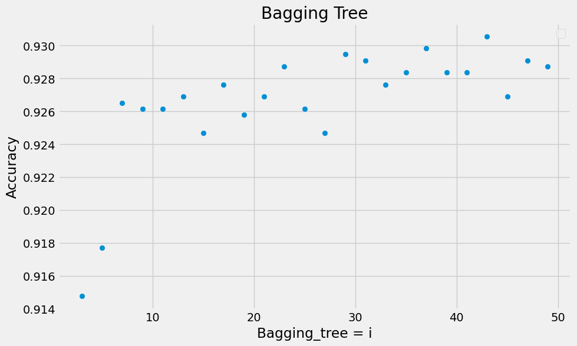

```python
from sklearn.tree import DecisionTreeClassifier
Bagging_tree = Bagging(DecisionTreeClassifier(max_depth=9),X_train_std, y_train_std, X_test_std, y_test_std)
_X = np.arange(3, 50, 2)
_Y = Bagging_tree[['Accuracy']]
display('Bagging_tree', Bagging_tree)
make_plot_scatter(_X, _Y, 'Bagging_tree = i', 'Accuracy', 'Bagging Tree', False)
```

### SVC

```
'Bagging_SVC'
```

|  | Model | Accuracy |
| --- | --- | --- |
| 0 | BaggingClassifierestimator=SVC, n_estimators=3 | 0.934240 |
| 1 | BaggingClassifierestimator=SVC, n_estimators=5 | 0.935709 |
| 2 | BaggingClassifierestimator=SVC, n_estimators=7 | 0.936076 |
| 3 | BaggingClassifierestimator=SVC, n_estimators=9 | 0.934607 |
| 4 | BaggingClassifierestimator=SVC, n_estimators=11 | 0.934607 |
| 5 | BaggingClassifierestimator=SVC, n_estimators=13 | 0.934607 |
| 6 | BaggingClassifierestimator=SVC, n_estimators=15 | 0.933872 |
| 7 | BaggingClassifierestimator=SVC, n_estimators=17 | 0.934607 |
| 8 | BaggingClassifierestimator=SVC, n_estimators=19 | 0.935709 |
| 9 | BaggingClassifierestimator=SVC, n_estimators=21 | 0.935709 |
| 10 | BaggingClassifierestimator=SVC, n_estimators=23 | 0.934974 |
| 11 | BaggingClassifierestimator=SVC, n_estimators=25 | 0.935342 |
| 12 | BaggingClassifierestimator=SVC, n_estimators=27 | 0.937179 |
| 13 | BaggingClassifierestimator=SVC, n_estimators=29 | 0.932403 |
| 14 | BaggingClassifierestimator=SVC, n_estimators=31 | 0.936076 |
| 15 | BaggingClassifierestimator=SVC, n_estimators=33 | 0.933505 |
| 16 | BaggingClassifierestimator=SVC, n_estimators=35 | 0.934607 |
| 17 | BaggingClassifierestimator=SVC, n_estimators=37 | 0.936076 |
| 18 | BaggingClassifierestimator=SVC, n_estimators=39 | 0.933872 |
| 19 | BaggingClassifierestimator=SVC, n_estimators=41 | 0.935709 |
| 20 | BaggingClassifierestimator=SVC, n_estimators=43 | 0.935342 |
| 21 | BaggingClassifierestimator=SVC, n_estimators=45 | 0.934607 |
| 22 | BaggingClassifierestimator=SVC, n_estimators=47 | 0.936076 |
| 23 | BaggingClassifierestimator=SVC, n_estimators=49 | 0.934974 |

```
No artists with labels found to put in legend.  Note that artists whose label start with an underscore are ignored when legend() is called with no argument.
```

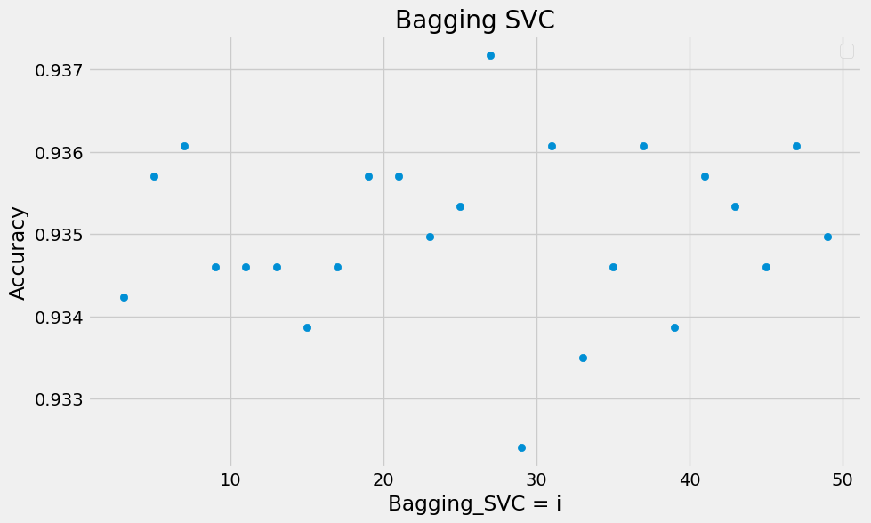

```python
from sklearn.svm import SVC
Bagging_SVC = Bagging(SVC(),X_train_std, y_train_std, X_test_std, y_test_std)
_X = np.arange(3, 50, 2)
_Y = Bagging_SVC[['Accuracy']]
display('Bagging_SVC', Bagging_SVC)
make_plot_scatter(_X, _Y, 'Bagging_SVC = i', 'Accuracy', 'Bagging SVC', False)
```

```python
max_bagging_naive = Bagging_naive.loc[[Bagging_naive['Accuracy'].idxmax()]]
max_bagging_KNN = Bagging_KNN.loc[[Bagging_KNN['Accuracy'].idxmax()]]
max_bagging_tree = Bagging_tree.loc[[Bagging_tree['Accuracy'].idxmax()]]
max_bagging_SVC = Bagging_SVC.loc[[Bagging_SVC['Accuracy'].idxmax()]]

df_bagging = pd.concat([max_bagging_naive, max_bagging_KNN, max_bagging_tree, max_bagging_SVC], axis=0)
df_bagging.round(decimals=4)
```

|  | Model | Accuracy |
| --- | --- | --- |
| 4 | BaggingClassifierestimator=GaussianNB, n_estim... | 0.8979 |
| 15 | BaggingClassifierestimator=KNeighborsClassifie... | 0.9302 |
| 20 | BaggingClassifierestimator=DecisionTreeClassif... | 0.9306 |
| 12 | BaggingClassifierestimator=SVC, n_estimators=27 | 0.9372 |

```python
display('Normal', df)
display('Bagging', df_bagging)
```

```
'Normal'
```

|  | Model | Accuracy |
| --- | --- | --- |
| 0 | GaussianNB | 0.897134 |
| 18 | KNeighborsClassifiern_neighbors=21 | 0.931668 |
| 7 | DecisionTreeClassifiermax_depth=9 | 0.914401 |
| 2 | SVC | 0.934240 |

```
'Bagging'
```

|  | Model | Accuracy |
| --- | --- | --- |
| 4 | BaggingClassifierestimator=GaussianNB, n_estim... | 0.897869 |
| 15 | BaggingClassifierestimator=KNeighborsClassifie... | 0.930198 |
| 20 | BaggingClassifierestimator=DecisionTreeClassif... | 0.930566 |
| 12 | BaggingClassifierestimator=SVC, n_estimators=27 | 0.937179 |

```python
df_ = df.rename(columns={'Accuracy': 'Normal'}).reset_index(drop=True)
df_bagging_ = df_bagging[['Accuracy']].rename(columns={'Accuracy': 'Bagging'}).reset_index(drop=True)
df_ = pd.concat([df_, df_bagging_], axis=1)
df_.round(decimals=3)
```

|  | Model | Normal | Bagging |
| --- | --- | --- | --- |
| 0 | GaussianNB | 0.897 | 0.898 |
| 1 | KNeighborsClassifiern_neighbors=21 | 0.932 | 0.930 |
| 2 | DecisionTreeClassifiermax_depth=9 | 0.914 | 0.931 |
| 3 | SVC | 0.934 | 0.937 |

Maka dapat disumpulkan Metode Bagging gaussian lebih unggul, metode normal KNN lebih unggul, Metode Bagging Decesion Tree lebih unggul, dan metode bangging svc lebih unggul

## RANDOM FOREST

#### Apa itu Random Forest?

Random Forest adalah algoritma pembelajaran ensemble yang menggunakan beberapa decision tree untuk meningkatkan performa prediksi dan mengurangi overfitting. Ini adalah salah satu metode paling populer dan kuat dalam pembelajaran mesin, baik untuk tugas klasifikasi maupun regresi.

#### Bagaimana Random Forest Bekerja?

1) Pengambilan Sampel Acak (Bootstrapping): Algoritma memulai dengan pengambilan sampel acak dengan penggantian (bootstrapping) dari dataset pelatihan asli untuk membuat beberapa subset data. 2) Membangun Decision Tree: Untuk setiap subset data, sebuah decision tree dibangun. Saat membangun setiap tree, hanya subset acak dari fitur yang dipertimbangkan untuk pembagian di setiap node (feature randomness). Ini membantu dalam menciptakan variasi di antara tree yang berbeda. 3) Prediksi Ensemble: Setelah semua decision tree dibangun, prediksi dilakukan dengan menggabungkan hasil dari semua tree. Untuk klasifikasi, prediksi akhir adalah kelas yang dipilih oleh mayoritas tree (voting mayoritas). Untuk regresi, prediksi akhir adalah rata-rata dari semua prediksi tree.

#### Keuntungan Random Forest

- Mengurangi Overfitting: Dengan menggabungkan hasil dari banyak decision tree, Random Forest mengurangi risiko overfitting yang sering terjadi pada single decision tree.
- Robustness: Tahan terhadap outlier dan data yang hilang.
- Flexibilitas: Dapat digunakan untuk tugas klasifikasi dan regresi.
- Feature Importance: Dapat memberikan informasi tentang pentingnya fitur (feature importance), membantu dalam memilih fitur yang relevan.

#### Kekurangan Random Forest

- Kompleksitas dan Waktu Komputasi: Membutuhkan lebih banyak sumber daya komputasi dan waktu untuk melatih dan membuat prediksi dibandingkan dengan decision tree tunggal.
- Kurang Interpretabilitas: Meskipun lebih akurat, hasil dari Random Forest lebih sulit untuk diinterpretasikan dibandingkan dengan single decision tree.

#### Langkah-langkah dalam Random Forest:

1) Membangun Forest:

```
- Mengambil sampel acak dengan penggantian dari dataset asli untuk membuat beberapa subset.
- Membangun decision tree untuk setiap subset dengan mempertimbangkan subset acak dari fitur untuk pembagian di setiap node.
```

2) Prediksi:

```
- Untuk klasifikasi: Voting mayoritas dari prediksi semua tree.
- Untuk regresi: Rata-rata dari semua prediksi tree.
```

```python
from sklearn.ensemble import RandomForestClassifier
def RandomForest(X_train, y_train, X_test, y_test):
    le = LabelEncoder()
    y_train = le.fit_transform(y_train)
    y_test = le.fit_transform(y_test)
    acc = []
    index = []
    for n in range(2, 20, 1):
        clf = RandomForestClassifier(n_estimators=10, max_depth=n, random_state=42)
        clf.fit(X_train, y_train.ravel())
        y_pred = clf.predict(X_test)
        accuracy = accuracy_score(y_pred, y_test)
        acc.append(accuracy)
        index.append(str(clf).replace('(', '').replace(')', ''))

    df = pd.DataFrame({
        'Model': index,
        'Accuracy': acc

    })
    return df

Random_forest = RandomForest(X_train_std, y_train_std, X_test_std, y_test_std)
Random_forest
```

|  | Model | Accuracy |
| --- | --- | --- |
| 0 | RandomForestClassifiermax_depth=2, n_estimator... | 0.778472 |
| 1 | RandomForestClassifiermax_depth=3, n_estimator... | 0.800147 |
| 2 | RandomForestClassifiermax_depth=4, n_estimator... | 0.883542 |
| 3 | RandomForestClassifiermax_depth=5, n_estimator... | 0.891256 |
| 4 | RandomForestClassifiermax_depth=6, n_estimator... | 0.899706 |
| 5 | RandomForestClassifiermax_depth=7, n_estimator... | 0.915871 |
| 6 | RandomForestClassifiermax_depth=8, n_estimator... | 0.921014 |
| 7 | RandomForestClassifiermax_depth=9, n_estimator... | 0.921014 |
| 8 | RandomForestClassifiermax_depth=10, n_estimato... | 0.922116 |
| 9 | RandomForestClassifiermax_depth=11, n_estimato... | 0.920279 |
| 10 | RandomForestClassifiermax_depth=12, n_estimato... | 0.925055 |
| 11 | RandomForestClassifiermax_depth=13, n_estimato... | 0.923953 |
| 12 | RandomForestClassifiermax_depth=14, n_estimato... | 0.924688 |
| 13 | RandomForestClassifiermax_depth=15, n_estimato... | 0.927627 |
| 14 | RandomForestClassifiermax_depth=16, n_estimato... | 0.921381 |
| 15 | RandomForestClassifiermax_depth=17, n_estimato... | 0.922851 |
| 16 | RandomForestClassifiermax_depth=18, n_estimato... | 0.925422 |
| 17 | RandomForestClassifiermax_depth=19, n_estimato... | 0.925422 |

```
No artists with labels found to put in legend.  Note that artists whose label start with an underscore are ignored when legend() is called with no argument.
```

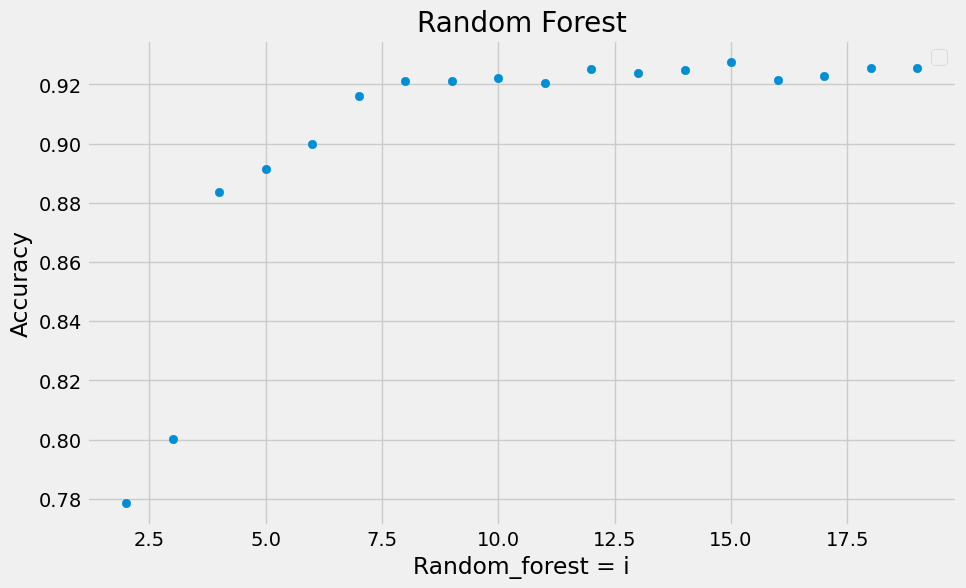

```python
_X = np.arange(2, 20, 1)
_Y = Random_forest[['Accuracy']]
make_plot_scatter(_X, _Y, 'Random_forest = i', 'Accuracy', 'Random Forest', False)
```

## STACKING

### PENGERTIAN METODE STACKING

Stacking adalah sebuah metode dimana sebuah model ditraining untuk menggabungkan beberapa individual model yang disebut *first-level learner*, sedangkan yang digabungkan disebut *second-level learner* atau *meta-learner*.

Stacking melibatkan dua atau lebih *base learner* atau model dasar sebagai model level-1, dan meta-learner yang menggabungkan prediksi base learner disebut sebagai level-2. Model yang berbeda digunakan oleh base learner untuk belajar dari suatu dataset. Output dari masing-masing model base learner dikumpulkan untuk membuat dataset baru. Di dalam dataset yang baru, setiap sampel berhubungan dengan nilai pada dataset awal yang seharusnya diprediksi. Selanjutnya dataset tersebut digunakan oleh model meta-learner hingga mendapatkan hasil akhir.

Dimana jika kita kita memvisualisasi menggunakan diagram sebagai berikut:

[figure not shown]

Deskripsi : 1) First-level Learner 2) Data set baru yang dihasilkan dari hasil pembelajaran first-level Learner 3) Meta Learner 4) Hasil Prediksi

### PERHITUNGAN METODE STACKING DENGAN MODEL TERBAIK

Kali ini kita akan melakukan perhitungan Stacking menggunakan model terbaik antara bagging dan normal :

```python
df_
```

|  | Model | Normal | Bagging |
| --- | --- | --- | --- |
| 0 | GaussianNB | 0.897134 | 0.897869 |
| 1 | KNeighborsClassifiern_neighbors=21 | 0.931668 | 0.930198 |
| 2 | DecisionTreeClassifiermax_depth=9 | 0.914401 | 0.930566 |
| 3 | SVC | 0.934240 | 0.937179 |

```python
from sklearn.ensemble import StackingClassifier
estimator = [
    ('naive', BaggingClassifier(estimator=GaussianNB(), n_estimators=15, random_state=None)),
    ('knn', KNeighborsClassifier(n_neighbors=21)),
    ('tree', BaggingClassifier(estimator=DecisionTreeClassifier(max_depth=9), n_estimators=43, random_state=None)),
    ('svc', BaggingClassifier(estimator=SVC(), n_estimators=27, random_state=None)),
]


clf_stacking = StackingClassifier(estimators=estimator, final_estimator=RandomForestClassifier(n_estimators=10, max_depth=9, random_state=42))
clf_stacking.fit(X_train_std, y_train_std)
y_pred = clf_stacking.predict(X_test_std)
accuracy = accuracy_score(y_pred, y_test_std)
accuracy
```

```
0.934974283614989
```

Maka didapatkan metode Stacking memiliki akurasi sedikit lebih rendah dengan metode Bagging SVC namun disini saya tetep memilih metode Stacking sebagai metode paling akurat dengan alasan metode stacking merupakan kumpulan dari berbagai model sehingga dapat menutupi kekurangan 1 sama lain dan model tersebut akan dimport dan di implemntasi ke halaman website

# IMPLEMENTASI MENJADI HALAMAN WEB

### Melakukan penyimpanan model menggunakan library joblib

```python
import joblib
joblib.dump(scaler_dm, 'scaler_std.joblib')
joblib.dump(clf_stacking, 'stacking_model.joblib')
```

## TATA CARA HOSTING WEB

### Masuk ke Cpanel lalu ke Setup Python App

[figure not shown]

### TEKAN TOMBOL CREATE APPLICATION

[figure not shown]

### LALU ISI SESUAI DENGAN KEINGINAN MU

[figure not shown]

### LALU KITA INSTALL LIBRARY YANG DIPERLUKAN DI BAGIAN PIP INSTALL

[figure not shown]

### LALU KITA UPLOAD FILE (File Manager) SESUAI DENGAN FILE DEVELOPMENT KITA

[figure not shown]

### WEB SIAP DIJALANKAN KETIK URL SESUAI YANG TELAH KITA TULIS

[figure not shown]

```python
from google.colab import drive
drive.mount('/content/drive')
```

```python
!jupyter nbconvert --to html .ipynb
```

[output not shown]

[output cut: 133 more lines]

[output not shown]

[figure not shown]